# DDS 6306 - Case Study #2

David Loveday

4/11/2021

## Youtube Presentation Link: https://www.youtube.com/watch?v=wSlwNIm8y2M

## GitHub Webpage Link: https://dloveday.github.io/

## Executive Summary

DDSAnalytics has concluded an initial analysis of employee attribute data which demonstrates the ability to predict, using a naïve Bayes classification model, an individual employee’s voluntary attrition potential, as well as their monthly income using a multiple linear regression model. Many of these explanatory attributes may already exist in employee files while the others could be easily, and cost-effectively, be collected.

The analysis found these independent variables to be most impactful and their specific demographic values to be most at-risk for attrition:

1. Does the employee work overtime? Most At-Risk: “Yes”
2. Employee’s total years with the Company Most At-Risk: 0 – 10
3. Employee’s martial status Most At-Risk: “Single”
4. Employee’s tenure in their current role Most At-Risk: 0 - 4
5. Monthly Income Most At-Risk: $0 - $5,811
6. Department in which employee works Most At-Risk: “Sales”
7. Role held by the employee Most At-Risk: “Sales Rep”
8. Age of employee Most At-Risk: 18 – 28
9. Employee’s tenure with their current manager Most At-Risk: 0 - 4

DDSAnalytics has also found that a relatively simple multiple linear regression (MLR) model can effectively describe, and predict, an employee’s monthly income.

The MLR model below achieves a statistically significant (p-value << 0.05) solution with an Adjusted R2 = 91%.

𝑴𝒐𝒏𝒕𝒉𝒍𝒚𝑰𝒏𝒄𝒐𝒎𝒆= 𝜷𝟎+𝜷𝟏𝑫𝒊𝒔𝒕𝒂𝒏𝒄𝒆+𝜷𝟐𝑱𝒐𝒃𝑳𝒆𝒗𝒆𝒍+𝜷𝟑𝑷𝒆𝒓𝒄𝑺𝒂𝒍𝒂𝒓𝒚𝑯𝒊𝒌𝒆+𝜷𝟒𝑻𝒐𝒕𝒂𝒍𝑾𝒐𝒓𝒌𝒊𝒏𝒈𝒀𝒆𝒂𝒓𝒔+𝜷𝟓𝒀𝒆𝒂𝒓𝒔𝑾𝒊𝒕𝒉𝑪𝒖𝒓𝒓𝒆𝒏𝒕𝑴𝒂𝒏𝒂𝒈𝒆𝒓

Residuals: Min 1Q Median 3Q Max -5759 -872 16 740 4035

Coefficients: Estimate Std. Error t value Pr(>|t|)  
𝜷𝟎 (Intercept) -1707.30 227.30 -7.51 1.5e-13 𝜷𝟏 DistanceFromHome -15.57 5.74 -2.71 0.0068 𝜷𝟐 JobLevel 3723.77 68.43 54.41 < 2e-16 𝜷𝟑 PercentSalaryHike 9.57 12.72 0.75 0.4519  
𝜷𝟒 TotalWorkingYears 68.12 10.41 6.54 1.0e-10 𝜷𝟓 YearsWithCurrManager -60.04 14.70 -4.09 4.8e-05

Residual standard error: 1370 on 864 degrees of freedom Multiple R-squared: 0.911, Adjusted R-squared: 0.911 F-statistic: 1.78e+03 on 5 and 864 DF, p-value: <2e-16

## Project Desciption

Talent management is defined as the iterative process of developing and retaining employees. It may include workforce planning, employee training programs, identifying high-potential employees and reducing/preventing voluntary employee turnover (attrition). To gain a competitive edge over its competition, DDSAnalytics is planning to leverage data science for talent management. The executive leadership has identified predicting employee turnover as its first application of data science for talent management. Before the business green lights the project, they have tasked your data science team to conduct an analysis of existing employee data.

## Project Deliverables

1. Identify the top factors which contribute tot turnover. Clearly document and defend the analysis.
2. Discuss any other material insights, trends, or observations gleaned from the dataset.
3. Construct models which predict attrition and monthly income

## Dataset Description

The dataset provided to the project team captures general demographic information for each employee (example: age, gender, marital status) company-specific information (example: total years with the company, department, role), along with employee-reported satisfaction scores for several areas (example: Work Life Balance, Environment Satisfaction).

- Total rows: 870
- Total gross/net columns: 36/32 – ID/EmployeeCount/Over18/StandardHours [Columns with singular values removed from the analysis]
- Character/Categorical Fields: 8
- Numeric Fields: 24 – 10 integer fields behave more as categorical variables

Mercifully, the dataset did not contain any missing or null values

## Initialize libraries

```r
library(ggplot2)
library(tidyverse)
library(dplyr)
library(tidyr)
library(maps)
library(ggthemes)
library(plotly)
library(reshape)
library(githubinstall)
library(envirofacts)
library(eia)
library(stringr)
library(mapproj)
library(countrycode)
library(WDI)
library(stringr)
library(jsonlite)
library(plyr)
library(Rmisc)
library(class)
library(caret)
library(e1071)
library(scales)
library(RCurl) #getURL
library(rvest) #html_table, html_node
library(maps)
library(fiftystater)
library(mapproj)
library(GGally)
library(fpp)
library(shiny)
library(psych)
library(Hmisc)
library(corrplot)
library(caTools)
library(rpart)
library(data.table)
library(DT)
library(gridExtra)
library(Metrics)
library(randomForest)
library(pROC)
library(car)
library(asbio)
library(boot)
library(DAAG)
library(olsrr)
```

## Import Data / Format & Condition

```r
path.employee.dB <- "C:\\Users\\dloveday\\Dropbox\\Family\\School\\SMU\\Courses\\Spring 2021\\DS 6306 - Doing Data Science\\Lecture Notes\\Unit 14 and 15 Case Study 2\\CaseStudy2-data.csv"

make.eda.plots <- "Yes"
  column.histograms <- "Yes"
  demographics.plots <- "Yes"
  correlation.matrix.plots <- "Yes"
#
######################## FORMAT & CONDITION dB ########################
#
employee.dB <- read.csv(path.employee.dB)
raw.employe.dB <- read.csv(path.employee.dB)
```

## Data Diagnostics

```r
count.duplicates <- sum(duplicated(employee.dB))
summary.employee.dB <- summary(employee.dB)
```

## Variable Conversions, Numericizations & Factorizations

```r
# Make corresponding numeric field for "Attrition", if 'Yes' (= 1), if 'No' (= 0)
employee.dB$Attrition.Numeric <- ifelse(employee.dB$Attrition == "Yes", 1, 0)

# Make corresponding numeric field for "BusinessTravel"
employee.dB$BusinessTravel.Non_Travel <- ifelse(employee.dB$BusinessTravel == "Non-Travel", 1, 0)
employee.dB$BusinessTravel.Travel_Rarely <- ifelse(employee.dB$BusinessTravel == "Travel_Rarely", 1, 0)
employee.dB$BusinessTravel.Travel_Frequently <- ifelse(employee.dB$BusinessTravel == "Travel_Frequently", 1, 0)

# Make corresponding numeric field for "Department"
employee.dB$Department.Sales <- ifelse(employee.dB$Department == "Sales", 1, 0)
employee.dB$Department.Research_Development <- ifelse(employee.dB$Department == "Research & Development", 1, 0)
employee.dB$Department.Human_Resources <- ifelse(employee.dB$Department == "Human Resources", 1, 0)

# Make corresponding numeric field for "EducationalField"
employee.dB$EducationField.LifeSciences <- ifelse(employee.dB$EducationField == "Life Sciences", 1, 0)
employee.dB$EducationField.Medical <- ifelse(employee.dB$EducationField == "Medical", 1, 0)
employee.dB$EducationField.Marketing <- ifelse(employee.dB$EducationField == "Marketing", 1, 0)
employee.dB$EducationField.TechnicalDegree <- ifelse(employee.dB$EducationField == "Technical Degree", 1, 0)
employee.dB$EducationField.Other <- ifelse(employee.dB$EducationField == "Other", 1, 0)
employee.dB$EducationField.HumanResources <- ifelse(employee.dB$EducationField == "Human Resources", 1, 0)

# Make corresponding numeric field for "Gender"
for (i in 1:nrow(employee.dB)){
  if(employee.dB$Gender[i] == "Male") (employee.dB$Gender.Numeric[i] <- 0)
  if(employee.dB$Gender[i] == "Female") (employee.dB$Gender.Numeric[i] <- 1)
}

# Make corresponding numeric field for "JobRole"
employee.dB$JobRole.SalesExecutive <- ifelse(employee.dB$JobRole == "Sales Executive", 1, 0)
employee.dB$JobRole.ResearchDirector <- ifelse(employee.dB$JobRole == "Research Director", 1, 0)
employee.dB$JobRole.ManufacturingDirector <- ifelse(employee.dB$JobRole == "Manufacturing Director", 1, 0)
employee.dB$JobRole.ResearchScientist <- ifelse(employee.dB$JobRole == "Research Scientist", 1, 0)
employee.dB$JobRole.SalesRepresentative <- ifelse(employee.dB$JobRole == "Sales Representative", 1, 0)
employee.dB$JobRole.HealthcareRepresentative <- ifelse(employee.dB$JobRole == "Healthcare Representative", 1, 0)
employee.dB$JobRole.Manager <- ifelse(employee.dB$JobRole == "Manager", 1, 0)
employee.dB$JobRole.HumanResources <- ifelse(employee.dB$JobRole == "Human Resources", 1, 0)
employee.dB$JobRole.LaboratoryTechnician <- ifelse(employee.dB$JobRole == "Laboratory Technician", 1, 0)

# Make corresponding numeric field for "MaritalStatus"
employee.dB$MaritalStatus.Divorced <- ifelse(employee.dB$MaritalStatus == "Divorced", 1, 0)
employee.dB$MaritalStatus.Single <- ifelse(employee.dB$MaritalStatus == "Single", 1, 0)
employee.dB$MaritalStatus.Married <- ifelse(employee.dB$MaritalStatus == "Married", 1, 0)

# Make corresponding numeric field for "OverTime"
for (i in 1:nrow(employee.dB)){
  if(employee.dB$OverTime[i] == "No") (employee.dB$OverTime.Numeric[i] <- 0)
  if(employee.dB$OverTime[i] == "Yes") (employee.dB$OverTime.Numeric[i] <- 1)
}



categorical.string.variables <- c("BusinessTravel", "Department", "EducationField", "Gender", "JobRole", "MaritalStatus", "OverTime")

categorical.string.binary.variables <- c("BusinessTravel.Non_Travel", "BusinessTravel.Travel_Rarely", "BusinessTravel.Travel_Frequently",
                                         "Department.Sales", "Department.Research_Development", "Department.Human_Resources",
                                         "EducationField.LifeSciences", "EducationField.Medical", "EducationField.Marketing", "EducationField.TechnicalDegree", "EducationField.Other", "EducationField.HumanResources",
                                         "Gender.Numeric",
                                         "JobRole.SalesExecutive", "JobRole.ResearchDirector", "JobRole.ManufacturingDirector", "JobRole.ResearchScientist", "JobRole.SalesRepresentative", "JobRole.HealthcareRepresentative", "JobRole.Manager", "JobRole.HumanResources", "JobRole.LaboratoryTechnician",
                                         "MaritalStatus.Divorced", "MaritalStatus.Single", "MaritalStatus.Married",
                                         "OverTime.Numeric")

categorical.numeric.variables <- c("Education", "EnvironmentSatisfaction", "JobInvolvement", "JobLevel", "JobSatisfaction", "NumCompaniesWorked", "PercentSalaryHike", "TrainingTimesLastYear", "WorkLifeBalance", "YearsAtCompany",  "YearsInCurrentRole", "YearsSinceLastPromotion", "YearsWithCurrManager")

continious.numeric.variables <- c("Age", "DailyRate", "DistanceFromHome", "EmployeeNumber", "HourlyRate", "MonthlyIncome", "MonthlyRate")

all.variables <- c(categorical.string.variables, categorical.numeric.variables, continious.numeric.variables)

all.evaluation.variables <- c(categorical.string.variables,
                              c("Education.Quartiles", "EnvironmentSatisfaction.Quartiles", "JobInvolvement.Quartiles", "JobLevel.Quartiles", "JobSatisfaction.Quartiles", "NumCompaniesWorked.Quartiles", "PercentSalaryHike.Quartiles", "TrainingTimesLastYear.Quartiles", "WorkLifeBalance.Quartiles", "YearsAtCompany.Quartiles",  "YearsInCurrentRole.Quartiles", "YearsSinceLastPromotion.Quartiles", "YearsWithCurrManager.Quartiles"),
                              c("Age.Quartiles", "DailyRate.Quartiles", "DistanceFromHome.Quartiles", "EmployeeNumber.Quartiles", "HourlyRate.Quartiles", "MonthlyIncome.Quartiles", "MonthlyRate.Quartiles")
                              )


# Calculate and Record Quartiles for All Numeric Variables
for (i in 1:length(categorical.numeric.variables)) {
  employee.dB[ ,paste0(categorical.numeric.variables[i],".Quartiles") ] <- cut(employee.dB[ ,categorical.numeric.variables[i]], 4, include.lowest = TRUE, labels = c("0-25%", "25-50%", "50-75%", "75-100%"))
}

for (i in 1:length(continious.numeric.variables)) {
  employee.dB[ ,paste0(continious.numeric.variables[i],".Quartiles") ] <- cut(employee.dB[ ,continious.numeric.variables[i]], 4, include.lowest = TRUE, labels = c("0-25%", "25-50%", "50-75%", "75-100%"))
}
```

## Calculate Attribute densities & correlations for total, retained employees, lost employee populations

```r
# Calculate Attrition Rate by Category - For All & Retained & Lost
categories.dB <- data.frame()

for (i in 1:length(all.evaluation.variables)) {
  #
  unique.vector.temp   <-   unique(employee.dB[, c(paste0(all.evaluation.variables[i]))])
  category.vector.temp <-   rep(c(paste0(all.evaluation.variables[i])), times = length(unique.vector.temp))
  category.dF.temp <- data.frame(Category = category.vector.temp, Variable = unique.vector.temp)
  #
  categories.dB <- rbind(categories.dB, category.dF.temp)
}

categories.dB$demographic <- paste0(categories.dB$Category," - ", categories.dB$Variable)

retained.employee.dB <- filter(employee.dB, employee.dB$Attrition == "No")
lost.employee.dB <- filter(employee.dB, employee.dB$Attrition == "Yes")

for (i in 1:nrow(categories.dB)) {
  #
  categories.dB$all.demographic.count[i] <- sum( ldply( employee.dB[, categories.dB$Category[i]], function(c) sum(c==categories.dB$Variable[i]) ) )

  categories.dB$retained.demographic.count[i] <- sum( ldply( retained.employee.dB[, categories.dB$Category[i]], function(c) sum(c==categories.dB$Variable[i]) ) )
  categories.dB$retained.demographic.density[i] <- categories.dB$retained.demographic.count[i] / nrow(retained.employee.dB)

  categories.dB$lost.demographic.count[i] <- sum( ldply( lost.employee.dB[, categories.dB$Category[i]], function(c) sum(c==categories.dB$Variable[i]) ) )
  categories.dB$lost.demographic.density[i] <- categories.dB$lost.demographic.count[i] / nrow(lost.employee.dB)
  #
}
categories.dB$demographic.density.contrast.delta <- categories.dB$lost.demographic.density - categories.dB$retained.demographic.density
categories.dB$demographic.density.contrast.perc <- (categories.dB$demographic.density.contrast.delta / categories.dB$retained.demographic.density) * 100
categories.dB$retention.rate <- categories.dB$retained.demographic.count/categories.dB$all.demographic.count
categories.dB$attrition.rate <- categories.dB$lost.demographic.count/categories.dB$all.demographic.count
#
```

## Calculate Pearson’s correlations & Chi-Square Test

```r
#
#### Define Numeric Fields to be Used for Correlation Matrix
correlation.matrix.vector <- c(categorical.numeric.variables, continious.numeric.variables, categorical.string.binary.variables)

correlation.mtx.employee.dB <- rcorr(   as.matrix(employee.dB[, c("Attrition.Numeric" ,correlation.matrix.vector)])   )
correlation.mtx.employee.dB.coeff <- correlation.mtx.employee.dB$r
correlation.mtx.employee.dB.p <- correlation.mtx.employee.dB$P

positive.over.correlation.mtx <- data.frame(matrix(nrow = 1, ncol = 3))
colnames(positive.over.correlation.mtx) <- c("Var1", "Var2", "correl.coeff")

negative.over.correlation.mtx <- data.frame(matrix(nrow = 1, ncol = 3))
colnames(negative.over.correlation.mtx) <- c("Var1", "Var2", "correl.coeff")


correlation.threshold <- 0.75

for (i in 1:ncol(correlation.mtx.employee.dB.coeff)) {
  for (j in 1:nrow(correlation.mtx.employee.dB.coeff)) {
    if (correlation.mtx.employee.dB.coeff[j,i] > correlation.threshold) {
      positive.over.correlation.mtx <- rbind(positive.over.correlation.mtx, c((colnames(correlation.mtx.employee.dB.coeff))[i], (rownames(correlation.mtx.employee.dB.coeff))[j],  correlation.mtx.employee.dB.coeff[j,i]              ))
    }
    if (correlation.mtx.employee.dB.coeff[j,i] < correlation.threshold*-1) {
      negative.over.correlation.mtx <- rbind(negative.over.correlation.mtx, c((colnames(correlation.mtx.employee.dB.coeff))[i], (rownames(correlation.mtx.employee.dB.coeff))[j],  correlation.mtx.employee.dB.coeff[j,i]              ))
    }
  }
}
positive.over.correlation.mtx <- filter(positive.over.correlation.mtx, positive.over.correlation.mtx$correl.coeff != 1 & !is.na(positive.over.correlation.mtx))
negative.over.correlation.mtx <- filter(negative.over.correlation.mtx, negative.over.correlation.mtx$correl.coeff != 1 & !is.na(negative.over.correlation.mtx))

######################################################################################################################################
################################################### CHI-SQUARED TEST (ATTRITION) ###################################################
######################################################################################################################################
#
employee.dB.chi.sq <- data.frame(Variable = correlation.matrix.vector)

for (i in 1:nrow(employee.dB.chi.sq)) {
  employee.dB.chi.sq$p.value[i] <- chisq.test(employee.dB$Attrition, employee.dB[,correlation.matrix.vector[i]])$p.value
}
influential.variables.chi.sq <- (filter(employee.dB.chi.sq, employee.dB.chi.sq$p.value < 0.05))$Variable

employee.dB.Categorical.Binary.chi.sq <- data.frame(Variable = categorical.string.binary.variables)

for (i in 1:nrow(employee.dB.Categorical.Binary.chi.sq)) {
  employee.dB.Categorical.Binary.chi.sq$p.value[i] <- chisq.test(employee.dB$Attrition, employee.dB[, categorical.string.binary.variables[i]])$p.value
}
#
######################################################################################################################################
################################################### CHI-SQUARED TEST (MONTHLYINCOME) ###################################################
######################################################################################################################################
#
employee.dB.chi.sq.MI <- data.frame(Variable = correlation.matrix.vector)

for (i in 1:nrow(employee.dB.chi.sq.MI)) {
  employee.dB.chi.sq.MI$p.value[i] <- chisq.test(employee.dB$MonthlyIncome, employee.dB[,correlation.matrix.vector[i]])$p.value
}
influential.variables.chi.sq.MI <- (filter(employee.dB.chi.sq.MI, employee.dB.chi.sq.MI$p.value < 0.05))$Variable

employee.dB.Categorical.Binary.chi.sq.MI <- data.frame(Variable = categorical.string.binary.variables)

for (i in 1:nrow(employee.dB.Categorical.Binary.chi.sq.MI)) {
  employee.dB.Categorical.Binary.chi.sq.MI$p.value[i] <- chisq.test(employee.dB$Attrition, employee.dB[, categorical.string.binary.variables[i]])$p.value
}
```

## STEP 1A - EDA - DEFINE PLOT FUNCTIONS

```r
continious.histogram.plot.single.variable <- function(x_name, fill_source) {
  #dev.new()
  employee.dB.plot <- employee.dB[, c(paste0(x_name), paste0(fill_source))]
  employee.dB.plot %>% ggplot(aes(x = employee.dB.plot[,1], y = ..density..))+
    theme_bw()+
    geom_histogram(alpha = 0.35, color = "grey80")+
    geom_density(aes(color = employee.dB.plot[,1]), alpha = 0.01, size = 0.85, show.legend = FALSE)+
    labs(x = x_name, fill = "Attrition")
}

continious.histogram.plot <- function(x_name, fill_source) {
  #dev.new()
  employee.dB.plot <- employee.dB[, c(paste0(x_name), paste0(fill_source))]
  employee.dB.plot %>% ggplot(aes(x = employee.dB.plot[,1], y = ..density.., fill = employee.dB.plot[,2]))+
    theme_bw()+
    geom_histogram(position = "dodge", alpha = 0.35, color = "grey80")+
    geom_density(aes(color = employee.dB.plot[,2]), alpha = 0.01, size = 0.85, show.legend = FALSE)+
    labs(x = x_name, fill = "Attrition")
}

categorical.barchart.plot.single.variable <- function(x_name, fill_source) {
  #dev.new()
  employee.dB.plot <- employee.dB[, c(paste0(x_name), paste0(fill_source))]

  employee.dB.plot.table.total <- data.frame(table(employee.dB.plot[,2]))
  var1.name <- employee.dB.plot.table.total[1,1]
  var1.freq <- employee.dB.plot.table.total[1,2]
  var2.name <- employee.dB.plot.table.total[2,1]
  var2.freq <- employee.dB.plot.table.total[2,2]


  employee.dB.plot.table <- table(employee.dB.plot)

  employee.dB.plot.table <- data.frame(table(employee.dB.plot))
  for (i in 1:nrow(employee.dB.plot.table)) {
    if (employee.dB.plot.table[i,2] == var1.name) { employee.dB.plot.table$Density[i] <- employee.dB.plot.table$Freq[i] / var1.freq }
    if (employee.dB.plot.table[i,2] == var2.name) { employee.dB.plot.table$Density[i] <- employee.dB.plot.table$Freq[i] / var2.freq }
  }

  employee.dB.plot.table %>% ggplot(aes(x = employee.dB.plot.table[,1], y = Density))+
    theme_bw()+
    geom_bar(stat = "identity", alpha = 0.35, color = "grey80")+
    labs(x = x_name)
}



categorical.barchart.plot <- function(x_name, fill_source) {
  #dev.new()
  employee.dB.plot <- employee.dB[, c(paste0(x_name), paste0(fill_source))]

  employee.dB.plot.table.total <- data.frame(table(employee.dB.plot[,2]))
  var1.name <- employee.dB.plot.table.total[1,1]
  var1.freq <- employee.dB.plot.table.total[1,2]
  var2.name <- employee.dB.plot.table.total[2,1]
  var2.freq <- employee.dB.plot.table.total[2,2]


  employee.dB.plot.table <- table(employee.dB.plot)

  employee.dB.plot.table <- data.frame(table(employee.dB.plot))
  for (i in 1:nrow(employee.dB.plot.table)) {
    if (employee.dB.plot.table[i,2] == var1.name) { employee.dB.plot.table$Density[i] <- employee.dB.plot.table$Freq[i] / var1.freq }
    if (employee.dB.plot.table[i,2] == var2.name) { employee.dB.plot.table$Density[i] <- employee.dB.plot.table$Freq[i] / var2.freq }
  }


  employee.dB.plot.table %>% ggplot(aes(x = employee.dB.plot.table[,1], y = Density, fill = employee.dB.plot.table[,2]))+
    theme_bw()+
    geom_bar(stat = "identity", position = "dodge", alpha = 0.35, color = "grey80")+
    labs(x = x_name, fill = fill_source)
}

continious.scatter.plot <- function(x_name, y_name, fill_source) {
  #dev.new()
  employee.dB.plot <- employee.dB[, c(paste0(x_name), paste0(y_name), paste0(fill_source))]
  employee.dB.plot %>% ggplot(aes(x = employee.dB.plot[,1], y = employee.dB.plot[,2], color = employee.dB.plot[,3]))+
    theme_bw()+
    geom_point(position = "jitter")+
    labs(x = x_name, y = "Attrition", color = "Attrition")
}
```

## STEP 1B - EDA - CREATE VISUALS

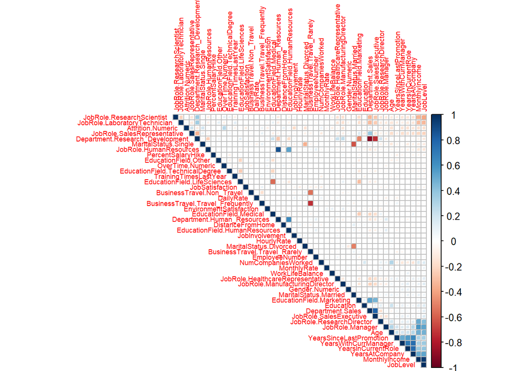

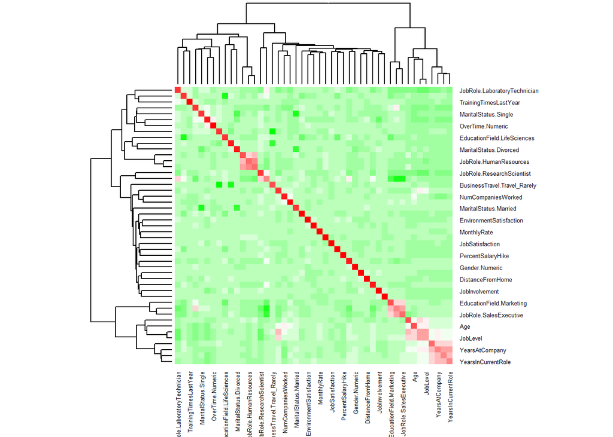

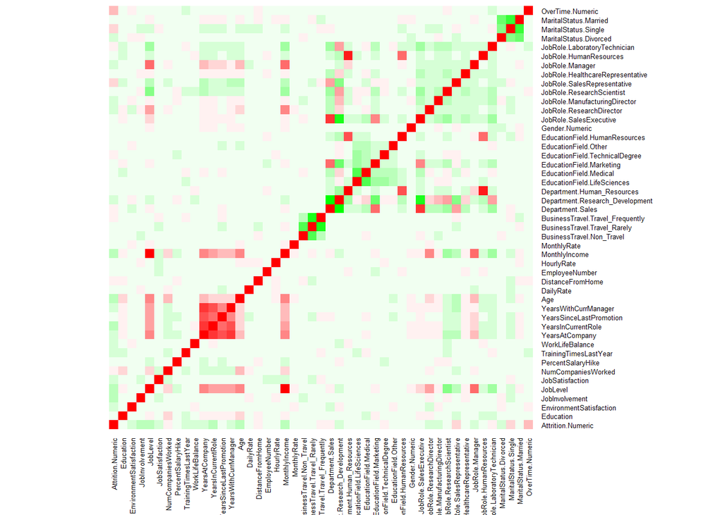

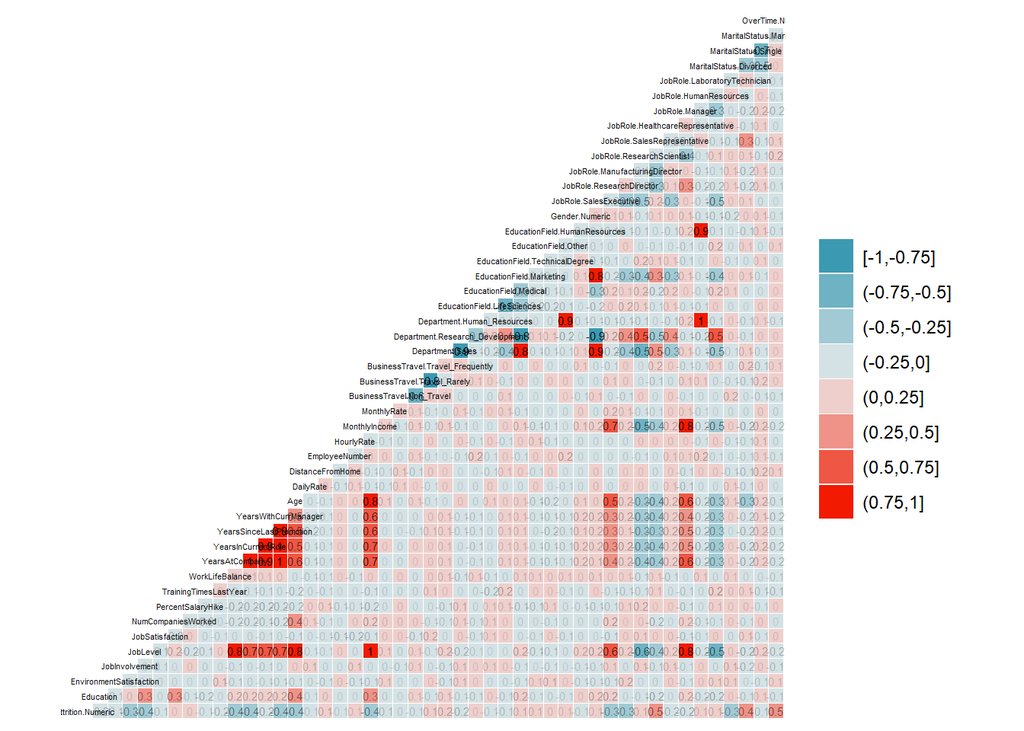

```r
if (make.eda.plots == "Yes") {

  if (column.histograms == "Yes") {
  #
  ##################
  ### CONTINIOUS VARIABLES ###
  ##################
  #
  ## AGE ##
  #continious.histogram.plot.single.variable("Age", "Attrition")
  #continious.histogram.plot("Age", "Attrition")

  ## BUSINESS TRAVEL ##
  continious.histogram.plot.single.variable("DailyRate", "Attrition")
  continious.histogram.plot("DailyRate", "Attrition")

  ## DISTANCE FROM HOME ##
  continious.histogram.plot.single.variable("DistanceFromHome", "Attrition")
  continious.histogram.plot("DistanceFromHome", "Attrition")

  ## EDUCATION ##
  continious.histogram.plot.single.variable("Education", "Attrition")
  continious.histogram.plot("Education", "Attrition")

  ## HOURLY RATE ##
  continious.histogram.plot.single.variable("HourlyRate", "Attrition")
  continious.histogram.plot("HourlyRate", "Attrition")

  ## MONTHLY INCOME ##
  continious.histogram.plot.single.variable("MonthlyIncome", "Attrition")
  continious.histogram.plot("MonthlyIncome", "Attrition")

  ## MONTHLY RATE ##
  continious.histogram.plot.single.variable("MonthlyRate", "Attrition")
  continious.histogram.plot("MonthlyRate", "Attrition")

  ## PERCENTAGE SALARY HIKE ##
  continious.histogram.plot.single.variable("PercentSalaryHike", "Attrition")
  continious.histogram.plot("PercentSalaryHike", "Attrition")

  ## TOTAL WORKING YEARS ##
  continious.histogram.plot.single.variable("TotalWorkingYears", "Attrition")
  continious.histogram.plot("TotalWorkingYears", "Attrition")

  ## YEARS AT COMPANY ##
  continious.histogram.plot.single.variable("YearsAtCompany", "Attrition")
  continious.histogram.plot("YearsAtCompany", "Attrition")

  ## YEARS IN CURRENT ROLE ##
  continious.histogram.plot.single.variable("YearsInCurrentRole", "Attrition")
  continious.histogram.plot("YearsInCurrentRole", "Attrition")



  ###################
  ### CATEGORICAL VARIABLES ###
  ###################
  #
  ## RAW ATTRITION ##
  #dev.new()
  employee.dB %>% ggplot(aes(x = Attrition, fill = Attrition))+
    theme_bw()+
    geom_bar(stat = "count", alpha = 0.35, color = "grey80", show.legend = FALSE)+
    labs(x = "Attrition", y = "Count")

  ## BUSINESS TRAVEL ##
  categorical.barchart.plot.single.variable("BusinessTravel", "Attrition")
  categorical.barchart.plot("BusinessTravel", "Attrition")

  ## DEPARTMENT ##
  categorical.barchart.plot.single.variable("Department", "Attrition")
  categorical.barchart.plot("Department", "Attrition")

  #dev.new()
  employee.dB %>% ggplot(aes(x = employee.dB$Department))+
    theme_bw()+
    geom_bar(stat = "count", alpha = 0.35, color = "grey80")+
    labs(x = "Department")


  ## ENVIRONMENTAL SATISFACTION ##
  categorical.barchart.plot.single.variable("EnvironmentSatisfaction", "Attrition")
  categorical.barchart.plot("EnvironmentSatisfaction", "Attrition")

  ## EDUCATION ##
  categorical.barchart.plot.single.variable("Education", "Attrition")
  categorical.barchart.plot("Education", "Attrition")

  ## EDUCATION FIELD ##
  categorical.barchart.plot.single.variable("EducationField", "Attrition")
  categorical.barchart.plot("EducationField", "Attrition")

  ## ENVIRONMENTAL SATISFACTION  ##
  categorical.barchart.plot.single.variable("EnvironmentSatisfaction", "Attrition")
  categorical.barchart.plot("EnvironmentSatisfaction", "Attrition")

  ## GENDER ##
  categorical.barchart.plot.single.variable("Gender", "Attrition")
  categorical.barchart.plot("Gender", "Attrition")

  ## JOB INVOLVEMENT ##
  categorical.barchart.plot.single.variable("JobInvolvement", "Attrition")
  categorical.barchart.plot("JobInvolvement", "Attrition")

  ## JOB LEVEL ##
  categorical.barchart.plot.single.variable("JobLevel", "Attrition")
  categorical.barchart.plot("JobLevel", "Attrition")

  ## JOB ROLE ##
  categorical.barchart.plot.single.variable("JobRole", "Attrition")
  categorical.barchart.plot("JobRole", "Attrition")

  ## JOB SATISFACTION ##
  categorical.barchart.plot.single.variable("JobSatisfaction", "Attrition")
  categorical.barchart.plot("JobSatisfaction", "Attrition")

  ## MARITAL STATUS ##
  categorical.barchart.plot.single.variable("MaritalStatus", "Attrition")
  categorical.barchart.plot("MaritalStatus", "Attrition")

  ## NUMBER OF COMPANIES WORKED ##
  categorical.barchart.plot.single.variable("NumCompaniesWorked", "Attrition")
  categorical.barchart.plot("NumCompaniesWorked", "Attrition")

  ## OVERTIME ##
  categorical.barchart.plot.single.variable("OverTime", "Attrition")
  categorical.barchart.plot("OverTime", "Attrition")

  ## PERFORMANCE RATING ##
  categorical.barchart.plot.single.variable("PerformanceRating", "Attrition")
  categorical.barchart.plot("PerformanceRating", "Attrition")

  ## RELATIONSHIP SATISFACTION ##
  categorical.barchart.plot.single.variable("RelationshipSatisfaction", "Attrition")
  categorical.barchart.plot("RelationshipSatisfaction", "Attrition")

  ## STOCK OPTION LEVEL ##
  categorical.barchart.plot.single.variable("StockOptionLevel", "Attrition")
  categorical.barchart.plot("StockOptionLevel", "Attrition")

  ## TRAINING TIMES LAST YEAR ##
  categorical.barchart.plot.single.variable("TrainingTimesLastYear", "Attrition")
  categorical.barchart.plot("TrainingTimesLastYear", "Attrition")

  ## WORKLIFE BALANCE ##
  categorical.barchart.plot.single.variable("WorkLifeBalance", "Attrition")
  categorical.barchart.plot("WorkLifeBalance", "Attrition")

  ## YEARS AT COMPANY ##
  categorical.barchart.plot.single.variable("YearsAtCompany", "Attrition")
  categorical.barchart.plot("YearsAtCompany", "Attrition")

  ## YEARS IN CURRENT ROLE  ##
  categorical.barchart.plot.single.variable("YearsInCurrentRole", "Attrition")
  categorical.barchart.plot("YearsInCurrentRole", "Attrition")

  ## YEARS SINCE LAST PROMOTION  ##
  categorical.barchart.plot.single.variable("YearsSinceLastPromotion", "Attrition")
  categorical.barchart.plot("YearsSinceLastPromotion", "Attrition")

  ## YEARS WITH CURRENT MANAGER  ##
  categorical.barchart.plot.single.variable("YearsWithCurrManager", "Attrition")
  categorical.barchart.plot("YearsWithCurrManager", "Attrition")

  #
  ###################
  ### TEMPORAL ###
  ###################
  #
  ## EMPLOYEE NUMBER ##
  continious.scatter.plot("EmployeeNumber", "Attrition.Numeric", "Attrition")
  }

  #
  ###################
  ### DEMOGRAPHICS ###
  ###################
  #
  if (demographics.plots == "Yes") {

    ## RETENTION DELTA FOR EACH DEMOGRAPHIC (BARCHART)
    #dev.new()
    categories.dB %>% arrange(desc(categories.dB$demographic.density.contrast.delta)) %>%
      ggplot(aes(x = reorder(demographic,-demographic.density.contrast.delta), y = demographic.density.contrast.delta, fill = Category ))+
      theme_bw()+
      theme(legend.key.width = unit(0.1,"cm"))+
      theme(legend.key.height = unit(0.2,"cm"))+
      theme(axis.text.x = element_text(size = 0.5))+
      theme(axis.text.x = element_text(angle = 45))+
      theme(legend.title = element_text(size = 1))+
      theme(legend.text = element_text(size = 5))+
      geom_bar(stat = "identity")+
      guides(fill = guide_legend(ncol = 1))+
      labs(x = "Demographic", y = "Population Denisty Delta")

    ## RETENTION DELTA FOR EACH DEMOGRAPHIC (BARCHART) - TOP 10
    #dev.new()
    categories.dB %>% arrange(desc(categories.dB$demographic.density.contrast.delta)) %>% head(10) %>%
      ggplot(aes(x = reorder(demographic,-demographic.density.contrast.delta), y = demographic.density.contrast.delta, fill = Category ))+
      theme_bw()+
      theme(legend.key.width = unit(0.1,"cm"))+
      theme(legend.key.height = unit(0.2,"cm"))+
      theme(axis.text.x = element_text(size = 10))+
      #theme(axis.text.x = element_text(angle = 45))+
      theme(legend.title = element_text(size = 1))+
      theme(legend.text = element_text(size = 1))+
      geom_bar(stat = "identity")+
      guides(fill = guide_legend(ncol = 1))+
      labs(x = "Demographic", y = "Demographic Denisty Contrast")

    ## RETENTION DELTA FOR EACH DEMOGRAPHIC (BARCHART) - BOTTOM 10
    #dev.new()
    categories.dB %>% arrange(desc(categories.dB$demographic.density.contrast.delta)) %>% tail(10) %>%
      ggplot(aes(x = reorder(demographic,-demographic.density.contrast.delta), y = demographic.density.contrast.delta, fill = Category ))+
      theme_bw()+
      theme(legend.key.width = unit(0.1,"cm"))+
      theme(legend.key.height = unit(0.2,"cm"))+
      theme(axis.text.x = element_text(size = 10))+
      #theme(axis.text.x = element_text(angle = 45))+
      theme(legend.title = element_text(size = 1))+
      theme(legend.text = element_text(size = 1))+
      geom_bar(stat = "identity")+
      guides(fill = guide_legend(ncol = 1))+
      labs(x = "Demographic", y = "Demographic Denisty Contrast")


    #######################################################################################

    ## DELTA PERCENTAGE FOR EACH DEMOGRAPHIC (BARCHART)
    #dev.new()
    categories.dB %>% arrange(desc(categories.dB$demographic.density.contrast.perc)) %>%
      ggplot(aes(x = reorder(demographic,-demographic.density.contrast.perc), y = demographic.density.contrast.perc, fill = Category ))+
      theme_bw()+
      theme(legend.key.width = unit(0.1,"cm"))+
      theme(legend.key.height = unit(0.2,"cm"))+
      theme(axis.text.x = element_text(size = 0.5))+
      theme(axis.text.x = element_text(angle = 45))+
      theme(legend.title = element_text(size = 1))+
      theme(legend.text = element_text(size = 5))+
      geom_bar(stat = "identity")+
      guides(fill = guide_legend(ncol = 1))+
      labs(x = "Demographic", y = "Population Denisty Delta Percentage (%)")

  } #DEMOGRAPHICS CLOSING BRACKETS

  #
  ###################
  ### CORRELATION MATRIX ###
  ###################
  #
  if (correlation.matrix.plots == "Yes") {
    #dev.new()
    corrplot(correlation.mtx.employee.dB.coeff, method = "square", type = "upper", order = "FPC", tl.cex = 0.55)

    #dev.new()
    palette = colorRampPalette(c("green", "white", "red")) (20)
    heatmap(x = correlation.mtx.employee.dB.coeff, col = palette, symm = TRUE, cexRow = 0.5, cexCol = 0.5, scale = "column")

    #dev.new()
    palette = colorRampPalette(c("green", "white", "red")) (20)
    heatmap(x = correlation.mtx.employee.dB.coeff, col = palette, symm = TRUE, Colv = NA, Rowv = NA, cexRow = 0.5, cexCol = 0.5)

    #dev.new()
    correlation.mtx.plot <- ggcorr(correlation.mtx.employee.dB.coeff, size = 1.5, label = TRUE, label_size = 2, label_color = "black", nbreaks = 8, label_alpha = TRUE, color = "grey5", layout.exp = 1)
    multiplot(correlation.mtx.plot)

    }
#
} # ALL EDA CLOSING BRACKET
```

## STEP 2 - CLASSIFICATION ANALYSIS

```r
alt.employee.dB <- read.csv(path.employee.dB)

attach(alt.employee.dB)

# Explore the raw data set
str(alt.employee.dB)
```

```
## 'data.frame':    870 obs. of  36 variables:
##  $ ID                      : int  1 2 3 4 5 6 7 8 9 10 ...
##  $ Age                     : int  32 40 35 32 24 27 41 37 34 34 ...
##  $ Attrition               : chr  "No" "No" "No" "No" ...
##  $ BusinessTravel          : chr  "Travel_Rarely" "Travel_Rarely" "Travel_Frequently" "Travel_Rarely" ...
##  $ DailyRate               : int  117 1308 200 801 567 294 1283 309 1333 653 ...
##  $ Department              : chr  "Sales" "Research & Development" "Research & Development" "Sales" ...
##  $ DistanceFromHome        : int  13 14 18 1 2 10 5 10 10 10 ...
##  $ Education               : int  4 3 2 4 1 2 5 4 4 4 ...
##  $ EducationField          : chr  "Life Sciences" "Medical" "Life Sciences" "Marketing" ...
##  $ EmployeeCount           : int  1 1 1 1 1 1 1 1 1 1 ...
##  $ EmployeeNumber          : int  859 1128 1412 2016 1646 733 1448 1105 1055 1597 ...
##  $ EnvironmentSatisfaction : int  2 3 3 3 1 4 2 4 3 4 ...
##  $ Gender                  : chr  "Male" "Male" "Male" "Female" ...
##  $ HourlyRate              : int  73 44 60 48 32 32 90 88 87 92 ...
```

[output cut: 22 more lines]

```r
#Convert characters to factors
alt.employee.dB$Attrition <- as.factor(alt.employee.dB$Attrition)
alt.employee.dB$BusinessTravel <- as.factor(alt.employee.dB$BusinessTravel)
alt.employee.dB$Department <- as.factor(alt.employee.dB$Department)
alt.employee.dB$EducationField <- as.factor(alt.employee.dB$EducationField)
alt.employee.dB$Gender <- as.factor(alt.employee.dB$Gender)
alt.employee.dB$JobRole <- as.factor(alt.employee.dB$JobRole)
alt.employee.dB$MaritalStatus <- as.factor(alt.employee.dB$MaritalStatus)
alt.employee.dB$Over18 <- as.factor(alt.employee.dB$Over18)
alt.employee.dB$OverTime <- as.factor(alt.employee.dB$OverTime)

# Coerce the integer (more or less categorical) variables in to factors
categorical.variables <- c('RelationshipSatisfaction', 'PerformanceRating', 'WorkLifeBalance', 'JobInvolvement', 'JobSatisfaction', 'JobLevel', 'StockOptionLevel')
alt.employee.dB[,categorical.variables] <- lapply(alt.employee.dB[,categorical.variables] , factor, ordered = TRUE)
str(alt.employee.dB)
```

```
## 'data.frame':    870 obs. of  36 variables:
##  $ ID                      : int  1 2 3 4 5 6 7 8 9 10 ...
##  $ Age                     : int  32 40 35 32 24 27 41 37 34 34 ...
##  $ Attrition               : Factor w/ 2 levels "No","Yes": 1 1 1 1 1 1 1 1 1 1 ...
##  $ BusinessTravel          : Factor w/ 3 levels "Non-Travel","Travel_Frequently",..: 3 3 2 3 2 2 3 3 3 2 ...
##  $ DailyRate               : int  117 1308 200 801 567 294 1283 309 1333 653 ...
##  $ Department              : Factor w/ 3 levels "Human Resources",..: 3 2 2 3 2 2 2 3 3 2 ...
##  $ DistanceFromHome        : int  13 14 18 1 2 10 5 10 10 10 ...
##  $ Education               : int  4 3 2 4 1 2 5 4 4 4 ...
##  $ EducationField          : Factor w/ 6 levels "Human Resources",..: 2 4 2 3 6 2 4 2 2 6 ...
##  $ EmployeeCount           : int  1 1 1 1 1 1 1 1 1 1 ...
##  $ EmployeeNumber          : int  859 1128 1412 2016 1646 733 1448 1105 1055 1597 ...
##  $ EnvironmentSatisfaction : int  2 3 3 3 1 4 2 4 3 4 ...
##  $ Gender                  : Factor w/ 2 levels "Female","Male": 2 2 2 1 1 2 2 1 1 2 ...
##  $ HourlyRate              : int  73 44 60 48 32 32 90 88 87 92 ...
```

[output cut: 22 more lines]

```r
# Calculate the Time an Employee spend at their last job
alt.employee.dB$TimeAtLastJob <- ifelse(alt.employee.dB$NumCompaniesWorked!=0, alt.employee.dB$TotalWorkingYears-alt.employee.dB$YearsAtCompany/alt.employee.dB$NumCompaniesWorked,0)
alt.employee.dB$AgeGroup <- as.factor(
                        ifelse(alt.employee.dB$Age<=30,"Early", ifelse(
                          alt.employee.dB$Age<=43,"Mid","Late"
                        ))
                      )
#convert MonthlyIncome
alt.employee.dB$MonthlyIncomeGroup <- as.factor(
  ifelse(alt.employee.dB$MonthlyIncome <= 2911,"1st.Quartile", ifelse(
    alt.employee.dB$MonthlyIncome <= 6503,"2nd.Quartile", ifelse(
      alt.employee.dB$MonthlyIncome <= 8379,"3rd.Quartile","4th.Quartile"
    )))
)
#convert  YearsAtCompany
alt.employee.dB$YrsAtCompanyGroup <- as.factor(
  ifelse(alt.employee.dB$YearsAtCompany <= 3,"1st.Quartile", ifelse(
    alt.employee.dB$YearsAtCompany <= 7,"2nd.Quartile", ifelse(
      alt.employee.dB$YearsAtCompany <= 10,"3rd.Quartile","4th.Quartile"
    )))
)
#convert YearsWithCurrManager
alt.employee.dB$YrsWtCurrManagerGroup <- as.factor(
  ifelse(alt.employee.dB$YearsWithCurrManager <= 2,"1st.Quartile", ifelse(
    alt.employee.dB$YearsWithCurrManager <= 4,"2nd.Quartile", ifelse(
      alt.employee.dB$YearsWithCurrManager <= 7,"3rd.Quartile","4th.Quartile"
    )))
)
#convert YearsInCurrentRole
alt.employee.dB$YrsInCurrentRoleGroup <- as.factor(
  ifelse(alt.employee.dB$YearsInCurrentRole <= 2,"LessTh2", ifelse(
    alt.employee.dB$YearsInCurrentRole <= 4,"2nd.Quartile", ifelse(
      alt.employee.dB$YearsInCurrentRole <= 7,"3rd.Quartile","4th.Quartile"
    )))
)

#create a new data frame with factors
alt.employee.dB_cat = alt.employee.dB[, c(2, 3, 4, 5, 6, 7, 8, 9, 12, 13, 14, 15, 16, 17, 18, 19, 20, 21, 22, 24, 25, 26, 27, 29, 30, 31, 32, 33, 34, 35, 36,  37, 38)]

#check for missing values
colSums(is.na(alt.employee.dB_cat))
```

```
##                      Age                Attrition           BusinessTravel
##                        0                        0                        0
##                DailyRate               Department         DistanceFromHome
##                        0                        0                        0
##                Education           EducationField  EnvironmentSatisfaction
##                        0                        0                        0
##                   Gender               HourlyRate           JobInvolvement
##                        0                        0                        0
##                 JobLevel                  JobRole          JobSatisfaction
##                        0                        0                        0
##            MaritalStatus            MonthlyIncome              MonthlyRate
##                        0                        0                        0
##       NumCompaniesWorked                 OverTime        PercentSalaryHike
##                        0                        0                        0
##        PerformanceRating RelationshipSatisfaction         StockOptionLevel
##                        0                        0                        0
##        TotalWorkingYears    TrainingTimesLastYear          WorkLifeBalance
##                        0                        0                        0
##           YearsAtCompany       YearsInCurrentRole  YearsSinceLastPromotion
##                        0                        0                        0
##     YearsWithCurrManager            TimeAtLastJob                 AgeGroup
##                        0                        0                        0
```

```r
#Split the Data
set.seed(1234)
alt.employee.dB_cat_split <- sample.split(alt.employee.dB_cat$Attrition, SplitRatio = 0.70)
alt.employee.dB_cat_train <- subset(alt.employee.dB_cat,alt.employee.dB_cat_split == T)
alt.employee.dB_cat_test <- subset(alt.employee.dB_cat,alt.employee.dB_cat_split == F)

# compare the dimention of splitted dataset
dim(alt.employee.dB_cat)
```

```
## [1] 870  33
```

```r
dim(alt.employee.dB_cat_test)
```

```
## [1] 261  33
```

```r
dim(alt.employee.dB_cat_train)
```

```
## [1] 609  33
```

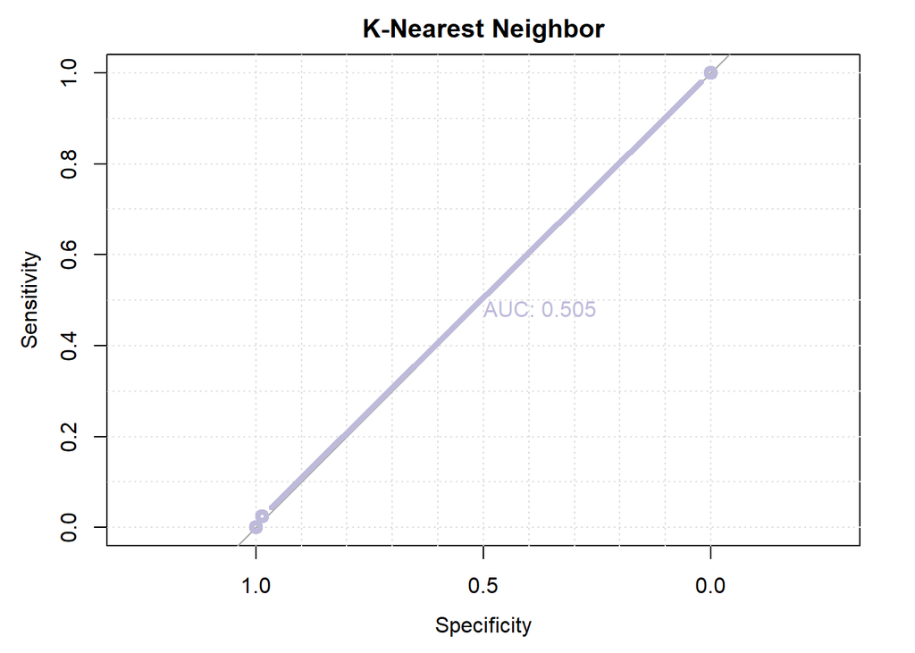

```r
################ kNN Classifier ################

#Fit the model on train data
KnnModel <- train(Attrition~.,alt.employee.dB_cat_train,method = 'knn',trControl = trainControl(method = 'repeatedcv',number = 3))
#Predict with test set
Knn_pred <- predict(KnnModel,alt.employee.dB_cat_test)
#Print confusion matrix
Knn_CM <- confusionMatrix(alt.employee.dB_cat_test$Attrition, Knn_pred)
#Plot the curve
plot.roc(as.numeric(alt.employee.dB_cat_test$Attrition), as.numeric(Knn_pred),lwd=4, type="b",grid.lty=3, grid=TRUE, print.auc=TRUE,print.auc.col= "#BEBADA", col ="#BEBADA", main = "K-Nearest Neighbor")
```

```r
################ Naive Bayes Classifier ################

# Fit the model on train data
NBModel <- naiveBayes(Attrition~., data=alt.employee.dB_cat_train)

# Validate on test set
NBM_pred <- predict(NBModel, newdata=alt.employee.dB_cat_test)

# Print confusion matrix
NBM_CM <- confusionMatrix(NBM_pred, alt.employee.dB_cat_test$Attrition)
NBM_CM
```

```
## Confusion Matrix and Statistics
##
##           Reference
## Prediction  No Yes
##        No  187  12
##        Yes  32  30
##
##                Accuracy : 0.8314
##                  95% CI : (0.7804, 0.8748)
##     No Information Rate : 0.8391
##     P-Value [Acc > NIR] : 0.668819
##
##                   Kappa : 0.4765
##
##  Mcnemar's Test P-Value : 0.004179
##
##             Sensitivity : 0.8539
##             Specificity : 0.7143
##          Pos Pred Value : 0.9397
##          Neg Pred Value : 0.4839
##              Prevalence : 0.8391
##          Detection Rate : 0.7165
##    Detection Prevalence : 0.7625
##       Balanced Accuracy : 0.7841
##
##        'Positive' Class : No
##
```

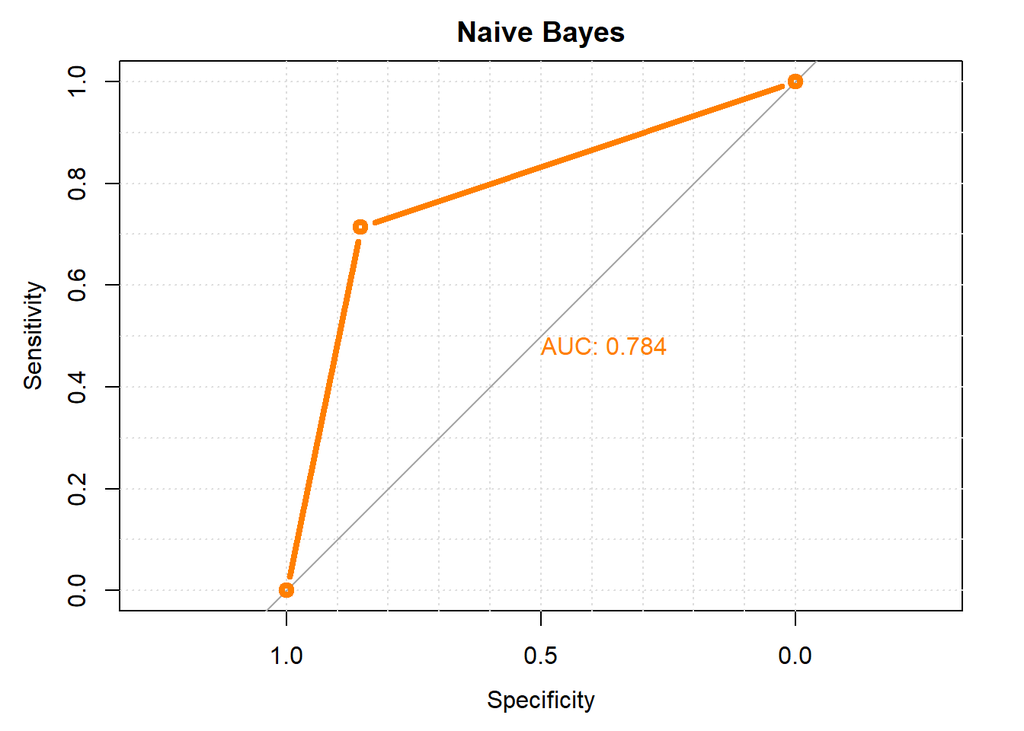

```r
#Plot
NBM_ROC <- plot.roc(as.numeric(alt.employee.dB_cat_test$Attrition), as.numeric(NBM_pred),lwd=4, type="b",grid.lty=3, grid=TRUE, print.auc=TRUE,print.auc.col= "#FF7F00", col ="#FF7F00", main ="Naive Bayes")
```

```r
NBM_ROC
```

```
##
## Call:
## plot.roc.default(x = as.numeric(alt.employee.dB_cat_test$Attrition),     predictor = as.numeric(NBM_pred), lwd = 4, type = "b", grid.lty = 3,     grid = TRUE, print.auc = TRUE, print.auc.col = "#FF7F00",     col = "#FF7F00", main = "Naive Bayes")
##
## Data: as.numeric(NBM_pred) in 219 controls (as.numeric(alt.employee.dB_cat_test$Attrition) 1) < 42 cases (as.numeric(alt.employee.dB_cat_test$Attrition) 2).
## Area under the curve: 0.7841
```

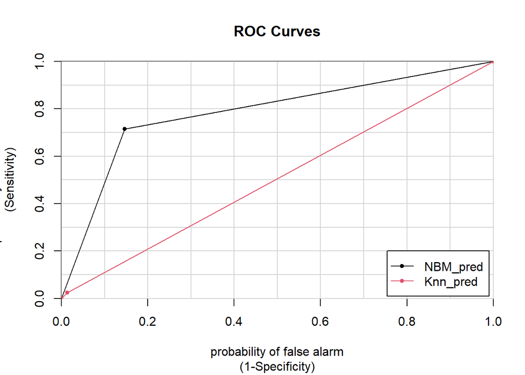

```
##             NBM_pred  Knn_pred
## No vs. Yes 0.7840835 0.5050554
```

```r
################ ROC Comaprison ################

#dev.new()
colAUC(cbind(NBM_pred, Knn_pred), alt.employee.dB_cat_test$Attrition, plotROC = TRUE)
```

```r
########################################################################
################ Generate Outputs for Grading Submission ###############

# Import & Condition Data
path.class.prediction.dB <- "C:\\Users\\dloveday\\Dropbox\\Family\\School\\SMU\\Courses\\Spring 2021\\DS 6306 - Doing Data Science\\Lecture Notes\\Unit 14 and 15 Case Study 2\\CaseStudy2CompSet No Attrition.csv"
class.prediction.dB <- read.csv(path.class.prediction.dB)

categorical.variables <- c('RelationshipSatisfaction', 'PerformanceRating', 'WorkLifeBalance', 'JobInvolvement', 'JobSatisfaction', 'JobLevel', 'StockOptionLevel')
class.prediction.dB[,categorical.variables] <- lapply(class.prediction.dB[,categorical.variables] , factor, ordered = TRUE)

class.prediction.dB$BusinessTravel <- as.factor(class.prediction.dB$BusinessTravel)
class.prediction.dB$Department <- as.factor(class.prediction.dB$Department)
class.prediction.dB$EducationField <- as.factor(class.prediction.dB$EducationField)
class.prediction.dB$Gender <- as.factor(class.prediction.dB$Gender)
class.prediction.dB$JobRole <- as.factor(class.prediction.dB$JobRole)
class.prediction.dB$MaritalStatus <- as.factor(class.prediction.dB$MaritalStatus)
class.prediction.dB$Over18 <- as.factor(class.prediction.dB$Over18)
class.prediction.dB$OverTime <- as.factor(class.prediction.dB$OverTime)

class.prediction.dB$TimeAtLastJob <- ifelse(class.prediction.dB$NumCompaniesWorked!=0, class.prediction.dB$TotalWorkingYears-class.prediction.dB$YearsAtCompany/class.prediction.dB$NumCompaniesWorked,0)

class.prediction.dB$TimeAtLastJob <- ifelse(class.prediction.dB$NumCompaniesWorked!=0, class.prediction.dB$TotalWorkingYears-class.prediction.dB$YearsAtCompany/class.prediction.dB$NumCompaniesWorked,0)
class.prediction.dB$AgeGroup <- as.factor(
  ifelse(class.prediction.dB$Age<=30,"Early", ifelse(
    class.prediction.dB$Age<=43,"Mid","Late"
  ))
)
#convert MonthlyIncome
class.prediction.dB$MonthlyIncomeGroup <- as.factor(
  ifelse(class.prediction.dB$MonthlyIncome <= 2911,"1st.Quartile", ifelse(
    class.prediction.dB$MonthlyIncome <= 6503,"2nd.Quartile", ifelse(
      class.prediction.dB$MonthlyIncome <= 8379,"3rd.Quartile","4th.Quartile"
    )))
)
#convert  YearsAtCompany
class.prediction.dB$YrsAtCompanyGroup <- as.factor(
  ifelse(class.prediction.dB$YearsAtCompany <= 3,"1st.Quartile", ifelse(
    class.prediction.dB$YearsAtCompany <= 7,"2nd.Quartile", ifelse(
      class.prediction.dB$YearsAtCompany <= 10,"3rd.Quartile","4th.Quartile"
    )))
)
#convert YearsWithCurrManager
class.prediction.dB$YrsWtCurrManagerGroup <- as.factor(
  ifelse(class.prediction.dB$YearsWithCurrManager <= 2,"1st.Quartile", ifelse(
    class.prediction.dB$YearsWithCurrManager <= 4,"2nd.Quartile", ifelse(
      class.prediction.dB$YearsWithCurrManager <= 7,"3rd.Quartile","4th.Quartile"
    )))
)
#convert YearsInCurrentRole
class.prediction.dB$YrsInCurrentRoleGroup <- as.factor(
  ifelse(class.prediction.dB$YearsInCurrentRole <= 2,"LessTh2", ifelse(
    class.prediction.dB$YearsInCurrentRole <= 4,"2nd.Quartile", ifelse(
      class.prediction.dB$YearsInCurrentRole <= 7,"3rd.Quartile","4th.Quartile"
    )))
)


# Make predictions using Test Model
class.prediction.dB$Attrition <- predict(NBModel, newdata=class.prediction.dB)

# Generate Outputs
write.csv(class.prediction.dB[, c("ID", "Attrition")], file.path("C:\\Users\\dloveday\\Dropbox\\Family\\School\\SMU\\Courses\\Spring 2021\\DS 6306 - Doing Data Science\\Lecture Notes\\Unit 14 and 15 Case Study 2\\DL Work\\Outputs for Submission\\","Case2PredictionsLoveday Attrition.csv"), row.names = FALSE)
```

## STEP 3 - MLR ANALYSIS FOR MonthlyIncome

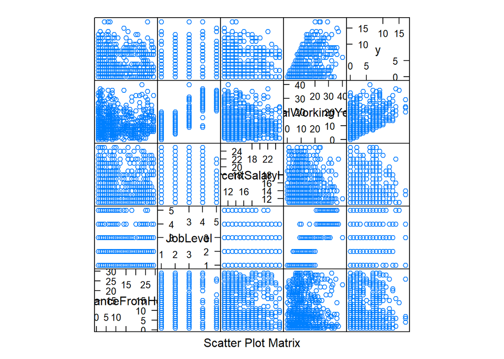

```r
# All Integer Variables in Dataset for MLR
employee.dB.integers <- employee.dB %>% select_if(is.integer)
employee.dB.integers <- employee.dB.integers[,c(2:ncol(employee.dB.integers))]

# Statistically Significant (p-value <0.05) Coefficient from Total Integer MLR Output
stat.signif.variables <- c("DistanceFromHome", "JobLevel", "PercentSalaryHike", "TotalWorkingYears", "YearsWithCurrManager", "MonthlyIncome")

subset.variables <- stat.signif.variables

employee.dB.MI <- as.data.frame(employee.dB[, c(subset.variables)])
employee.dB.MI.log <- log(employee.dB.MI)
employee.dB.MI.sqrt <- sqrt(employee.dB.MI)

#dev.new()
featurePlot(x=employee.dB.MI[,1:4], y=employee.dB.MI[,5], plot="pairs", auto.key=list(columns=3))
```

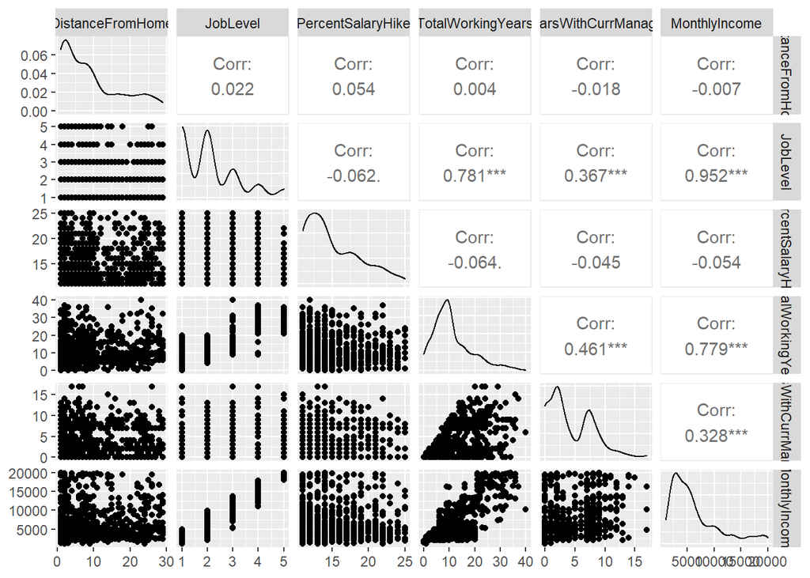

```r
#dev.new()
ggpairs(employee.dB.MI)
```

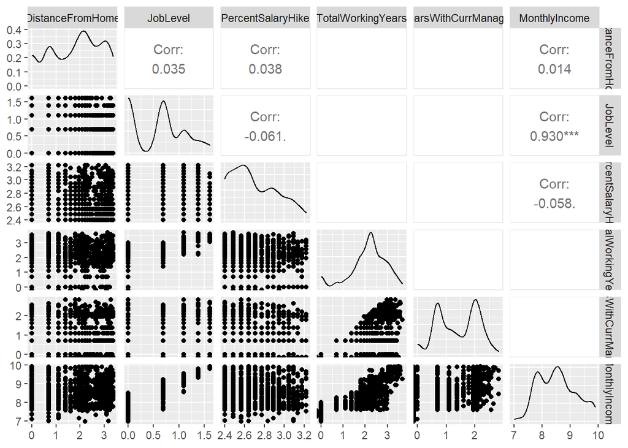

```r
#dev.new()
ggpairs(employee.dB.MI.log)
```

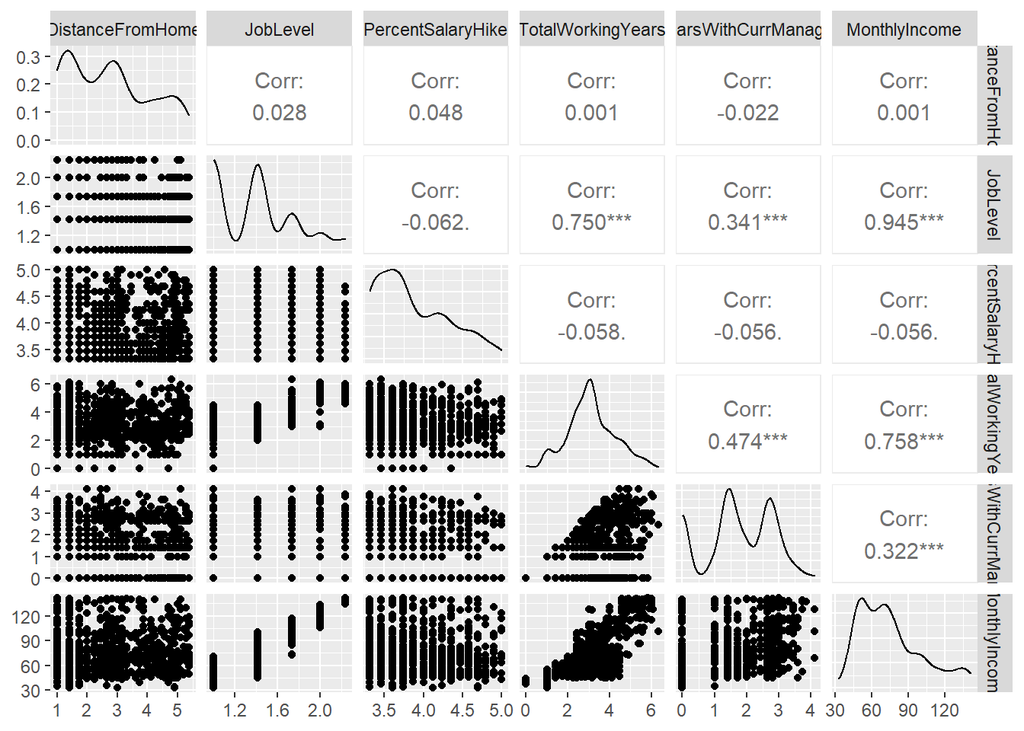

```r
#dev.new()
ggpairs(employee.dB.MI.sqrt)
```

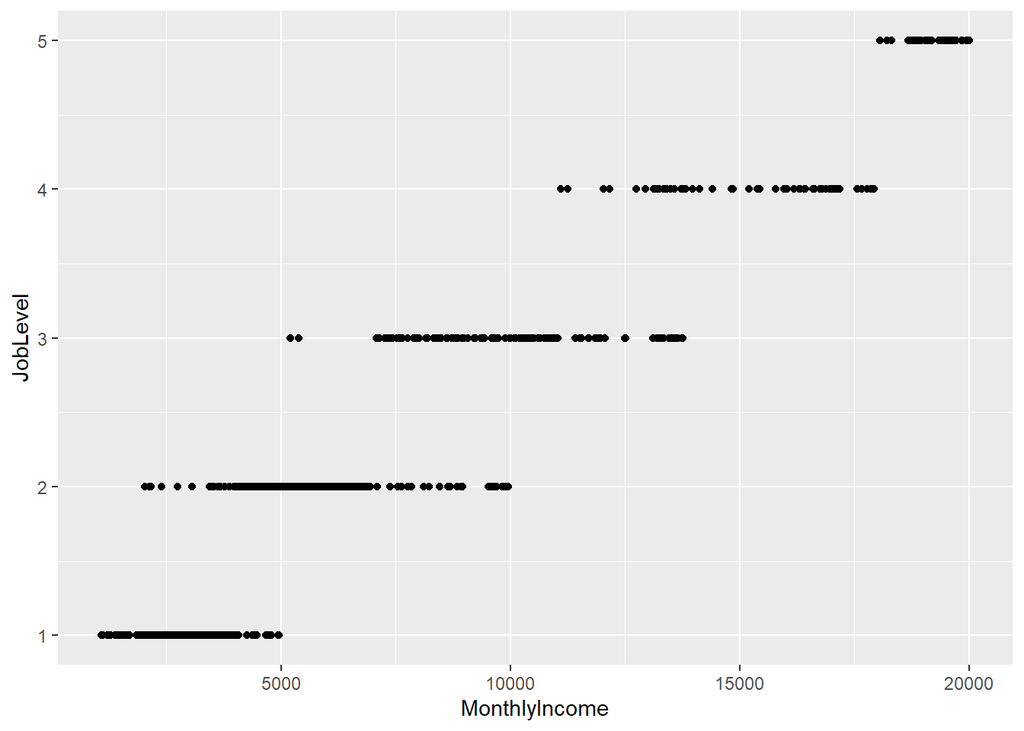

```r
#dev.new()
employee.dB.MI %>% ggplot(aes(x = MonthlyIncome, y = JobLevel))+
  geom_point()
```

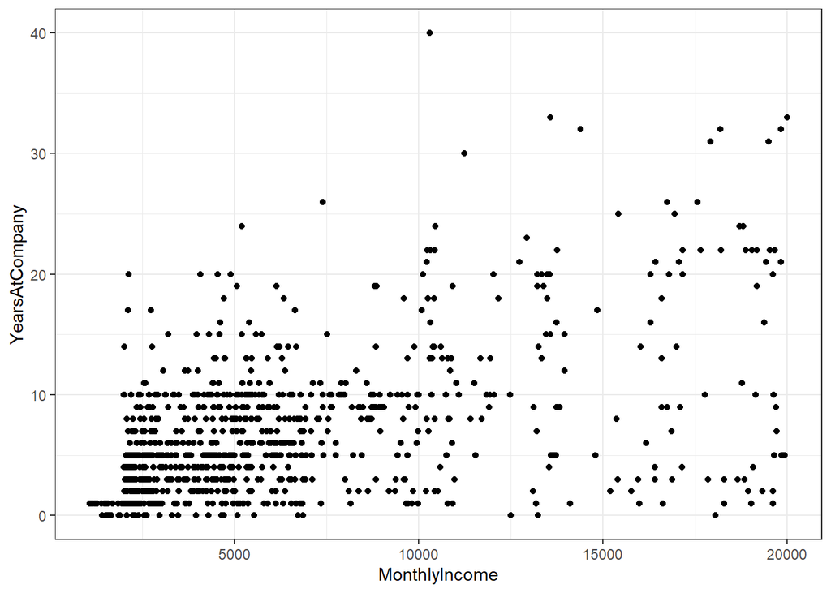

```r
#dev.new()
employee.dB.MI %>% ggplot(aes(x = MonthlyIncome, y = YearsAtCompany))+
  theme_bw()+
  geom_point()
```

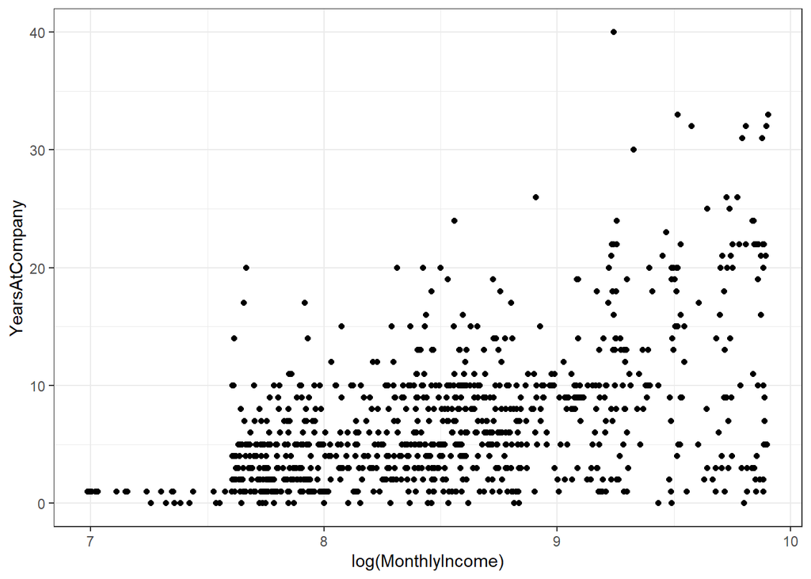

```r
#dev.new()
employee.dB.MI %>% ggplot(aes(x = log(MonthlyIncome), y = YearsAtCompany))+
  theme_bw()+
  geom_point()
```

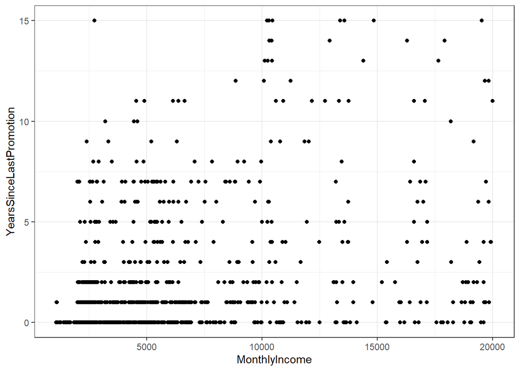

```r
#dev.new()
employee.dB.MI %>% ggplot(aes(x = MonthlyIncome, y = YearsSinceLastPromotion))+
  theme_bw()+
  geom_point()
```

```r
############### MLR MODEL BUILDING (USING ALL GIVEN DATA) ###############

# All integer column model
fit1 <- lm(MonthlyIncome ~ Age + DailyRate + DistanceFromHome + Education + EmployeeNumber + EnvironmentSatisfaction + HourlyRate +
             JobInvolvement + JobLevel + JobSatisfaction + MonthlyRate + NumCompaniesWorked + PercentSalaryHike + PerformanceRating +
             RelationshipSatisfaction + StockOptionLevel + TotalWorkingYears + TrainingTimesLastYear + WorkLifeBalance + YearsAtCompany + YearsInCurrentRole +
             YearsSinceLastPromotion + YearsWithCurrManager, data = employee.dB)
summary(fit1)
```

```
##
## Call:
## lm(formula = MonthlyIncome ~ Age + DailyRate + DistanceFromHome +
##     Education + EmployeeNumber + EnvironmentSatisfaction + HourlyRate +
##     JobInvolvement + JobLevel + JobSatisfaction + MonthlyRate +
##     NumCompaniesWorked + PercentSalaryHike + PerformanceRating +
##     RelationshipSatisfaction + StockOptionLevel + TotalWorkingYears +
##     TrainingTimesLastYear + WorkLifeBalance + YearsAtCompany +
##     YearsInCurrentRole + YearsSinceLastPromotion + YearsWithCurrManager,
##     data = employee.dB)
##
## Residuals:
##     Min      1Q  Median      3Q     Max
## -5781.6  -841.4    36.2   692.0  4026.8
##
## Coefficients:
##                            Estimate Std. Error t value Pr(>|t|)
## (Intercept)              -1.077e+03  6.697e+02  -1.608   0.1081
## Age                      -3.440e+00  7.237e+00  -0.475   0.6347
## DailyRate                -4.737e-02  1.180e-01  -0.402   0.6882
## DistanceFromHome         -1.665e+01  5.830e+00  -2.856   0.0044 **
## Education                 2.772e+00  4.766e+01   0.058   0.9536
## EmployeeNumber            6.912e-02  7.819e-02   0.884   0.3769
## EnvironmentSatisfaction  -6.656e+01  4.298e+01  -1.549   0.1218
## HourlyRate                1.566e+00  2.359e+00   0.664   0.5071
## JobInvolvement            1.021e+02  6.737e+01   1.516   0.1300
## JobLevel                  3.732e+03  6.975e+01  53.501  < 2e-16 ***
## JobSatisfaction          -6.436e+00  4.272e+01  -0.151   0.8803
## MonthlyRate              -5.185e-03  6.676e-03  -0.777   0.4376
## NumCompaniesWorked       -1.228e+01  2.159e+01  -0.568   0.5698
## PercentSalaryHike         3.542e+01  2.035e+01   1.740   0.0821 .
## PerformanceRating        -3.277e+02  2.077e+02  -1.578   0.1150
## RelationshipSatisfaction  1.674e+01  4.289e+01   0.390   0.6964
## StockOptionLevel          2.174e+00  5.566e+01   0.039   0.9688
## TotalWorkingYears         7.539e+01  1.386e+01   5.439 7.03e-08 ***
## TrainingTimesLastYear     1.795e+01  3.717e+01   0.483   0.6292
## WorkLifeBalance          -3.941e+01  6.653e+01  -0.592   0.5538
## YearsAtCompany           -1.048e+01  1.747e+01  -0.600   0.5487
## YearsInCurrentRole       -5.681e+00  2.177e+01  -0.261   0.7941
## YearsSinceLastPromotion   3.451e+00  1.954e+01   0.177   0.8599
## YearsWithCurrManager     -5.153e+01  2.138e+01  -2.410   0.0162 *
## ---
## Signif. codes:  0 '***' 0.001 '**' 0.01 '*' 0.05 '.' 0.1 ' ' 1
##
## Residual standard error: 1378 on 846 degrees of freedom
## Multiple R-squared:  0.9125, Adjusted R-squared:  0.9101
## F-statistic: 383.6 on 23 and 846 DF,  p-value: < 2.2e-16
```

```r
vif(fit1)
```

```
##                      Age                DailyRate         DistanceFromHome
##                   1.9085                   1.0242                   1.0293
##                Education           EmployeeNumber  EnvironmentSatisfaction
##                   1.0872                   1.0227                   1.0213
##               HourlyRate           JobInvolvement                 JobLevel
##                   1.0314                   1.0278                   2.6440
##          JobSatisfaction              MonthlyRate       NumCompaniesWorked
##                   1.0367                   1.0300                   1.3550
##        PercentSalaryHike        PerformanceRating RelationshipSatisfaction
##                   2.5595                   2.5423                   1.0228
##         StockOptionLevel        TotalWorkingYears    TrainingTimesLastYear
##                   1.0425                   4.9611                   1.0235
##          WorkLifeBalance           YearsAtCompany       YearsInCurrentRole
##                   1.0262                   5.0611                   2.8697
##  YearsSinceLastPromotion     YearsWithCurrManager
##                   1.7731                   2.6720
```

```r
AIC(fit1)
```

```
## [1] 15072.51
```

```r
BIC(fit1)
```

```
## [1] 15191.72
```

```r
press(fit1)
```

```
## [1] 1706123885
```

```r
# Only statistically significant variables
fit2 <- lm(MonthlyIncome ~ DistanceFromHome + JobLevel + PercentSalaryHike + TotalWorkingYears + YearsWithCurrManager, data = employee.dB)
summary(fit2)
```

```
##
## Call:
## lm(formula = MonthlyIncome ~ DistanceFromHome + JobLevel + PercentSalaryHike +
##     TotalWorkingYears + YearsWithCurrManager, data = employee.dB)
##
## Residuals:
##     Min      1Q  Median      3Q     Max
## -5758.7  -871.9    16.4   739.8  4035.5
##
## Coefficients:
##                       Estimate Std. Error t value Pr(>|t|)
## (Intercept)          -1707.304    227.298  -7.511 1.46e-13 ***
## DistanceFromHome       -15.572      5.737  -2.714  0.00678 **
## JobLevel              3723.772     68.435  54.413  < 2e-16 ***
## PercentSalaryHike        9.575     12.723   0.753  0.45194
## TotalWorkingYears       68.123     10.408   6.545 1.02e-10 ***
## YearsWithCurrManager   -60.036     14.696  -4.085 4.81e-05 ***
## ---
## Signif. codes:  0 '***' 0.001 '**' 0.01 '*' 0.05 '.' 0.1 ' ' 1
##
## Residual standard error: 1373 on 864 degrees of freedom
## Multiple R-squared:  0.9113, Adjusted R-squared:  0.9108
## F-statistic:  1776 on 5 and 864 DF,  p-value: < 2.2e-16
```

```r
vif(fit2)
```

```
##     DistanceFromHome             JobLevel    PercentSalaryHike
##               1.0044               2.5650               1.0079
##    TotalWorkingYears YearsWithCurrManager
##               2.8188               1.2717
```

```r
AIC(fit2)
```

```
## [1] 15048.17
```

```r
BIC(fit2)
```

```
## [1] 15081.55
```

```r
press(fit2)
```

```
## [1] 1654520853
```

```r
fit2b <- lm(MonthlyIncome ~ DistanceFromHome + JobLevel + TotalWorkingYears + YearsWithCurrManager, data = employee.dB)
summary(fit2b)
```

```
##
## Call:
## lm(formula = MonthlyIncome ~ DistanceFromHome + JobLevel + TotalWorkingYears +
##     YearsWithCurrManager, data = employee.dB)
##
## Residuals:
##     Min      1Q  Median      3Q     Max
## -5775.8  -859.8    21.0   727.6  4022.3
##
## Coefficients:
##                       Estimate Std. Error t value Pr(>|t|)
## (Intercept)          -1559.495    114.362 -13.637  < 2e-16 ***
## DistanceFromHome       -15.335      5.727  -2.677  0.00756 **
## JobLevel              3722.700     68.403  54.423  < 2e-16 ***
## TotalWorkingYears       67.981     10.404   6.534 1.09e-10 ***
## YearsWithCurrManager   -60.215     14.690  -4.099 4.54e-05 ***
## ---
## Signif. codes:  0 '***' 0.001 '**' 0.01 '*' 0.05 '.' 0.1 ' ' 1
##
## Residual standard error: 1373 on 865 degrees of freedom
## Multiple R-squared:  0.9113, Adjusted R-squared:  0.9108
## F-statistic:  2221 on 4 and 865 DF,  p-value: < 2.2e-16
```

```r
vif(fit2b)
```

```
##     DistanceFromHome             JobLevel    TotalWorkingYears
##               1.0014               2.5639               2.8179
## YearsWithCurrManager
##               1.2714
```

```r
AIC(fit2b)
```

```
## [1] 15046.74
```

```r
BIC(fit2b)
```

```
## [1] 15075.35
```

```r
press(fit2b)
```

```
## [1] 1651820568
```

```r
# Log
#fit2c <- lm(MonthlyIncome ~ DistanceFromHome + JobLevel + TotalWorkingYears + YearsWithCurrManager, data = employee.dB.MI.log)
#summary(fit2c)
#vif(fit2c)
#AIC(fit2c)
#BIC(fit2c)
#press(fit2c)

# Sqrt
fit2d <- lm(MonthlyIncome ~ DistanceFromHome + JobLevel + TotalWorkingYears + YearsWithCurrManager, data = employee.dB.MI.sqrt)
summary(fit2d)
```

```
##
## Call:
## lm(formula = MonthlyIncome ~ DistanceFromHome + JobLevel + TotalWorkingYears +
##     YearsWithCurrManager, data = employee.dB.MI.sqrt)
##
## Residuals:
##     Min      1Q  Median      3Q     Max
## -34.628  -5.031  -0.026   4.938  24.171
##
## Coefficients:
##                      Estimate Std. Error t value Pr(>|t|)
## (Intercept)          -16.6268     1.2462 -13.342  < 2e-16 ***
## DistanceFromHome      -0.4810     0.2122  -2.266  0.02368 *
## JobLevel              62.0347     1.1755  52.772  < 2e-16 ***
## TotalWorkingYears      2.9501     0.4005   7.366  4.1e-13 ***
## YearsWithCurrManager  -0.8087     0.2999  -2.696  0.00715 **
## ---
## Signif. codes:  0 '***' 0.001 '**' 0.01 '*' 0.05 '.' 0.1 ' ' 1
##
## Residual standard error: 8.3 on 865 degrees of freedom
## Multiple R-squared:  0.8998, Adjusted R-squared:  0.8993
## F-statistic:  1941 on 4 and 865 DF,  p-value: < 2.2e-16
```

```r
vif(fit2d)
```

```
##     DistanceFromHome             JobLevel    TotalWorkingYears
##               1.0024               2.2950               2.6120
## YearsWithCurrManager
##               1.2912
```

```r
AIC(fit2d)
```

```
## [1] 6158.224
```

```r
BIC(fit2d)
```

```
## [1] 6186.835
```

```r
press(fit2d)
```

```
## [1] 60275.97
```

```r
# Chi-Squared Impactful Variable Model
fit3 <- lm(MonthlyIncome ~ JobLevel + YearsAtCompany + YearsSinceLastPromotion + YearsWithCurrManager + Age, data = employee.dB)
summary(fit3)
```

```
##
## Call:
## lm(formula = MonthlyIncome ~ JobLevel + YearsAtCompany + YearsSinceLastPromotion +
##     YearsWithCurrManager + Age, data = employee.dB)
##
## Residuals:
##     Min      1Q  Median      3Q     Max
## -5112.3  -960.7    53.5   745.0  3769.4
##
## Coefficients:
##                          Estimate Std. Error t value Pr(>|t|)
## (Intercept)             -2251.583    205.015 -10.983  < 2e-16 ***
## JobLevel                 3951.274     55.928  70.650  < 2e-16 ***
## YearsAtCompany             15.347     14.859   1.033  0.30197
## YearsSinceLastPromotion     8.716     19.570   0.445  0.65617
## YearsWithCurrManager      -51.385     20.753  -2.476  0.01347 *
## Age                        18.243      6.099   2.991  0.00286 **
## ---
## Signif. codes:  0 '***' 0.001 '**' 0.01 '*' 0.05 '.' 0.1 ' ' 1
##
## Residual standard error: 1403 on 864 degrees of freedom
## Multiple R-squared:  0.9074, Adjusted R-squared:  0.9068
## F-statistic:  1692 on 5 and 864 DF,  p-value: < 2.2e-16
```

```r
vif(fit3)
```

```
##                JobLevel          YearsAtCompany YearsSinceLastPromotion
##                  1.6398                  3.5312                  1.7150
##    YearsWithCurrManager                     Age
##                  2.4276                  1.3074
```

```r
AIC(fit3)
```

```
## [1] 15086.22
```

```r
BIC(fit3)
```

```
## [1] 15119.6
```

```r
press(fit3)
```

```
## [1] 1729161252
```

```r
#
Q2_fit_forward <- ols_step_forward_p(fit1, penter = 0.05, details = TRUE)
```

```
## Forward Selection Method
## ---------------------------
##
## Candidate Terms:
##
## 1. Age
## 2. DailyRate
## 3. DistanceFromHome
## 4. Education
## 5. EmployeeNumber
## 6. EnvironmentSatisfaction
## 7. HourlyRate
## 8. JobInvolvement
## 9. JobLevel
## 10. JobSatisfaction
## 11. MonthlyRate
## 12. NumCompaniesWorked
## 13. PercentSalaryHike
## 14. PerformanceRating
## 15. RelationshipSatisfaction
## 16. StockOptionLevel
## 17. TotalWorkingYears
## 18. TrainingTimesLastYear
## 19. WorkLifeBalance
## 20. YearsAtCompany
## 21. YearsInCurrentRole
## 22. YearsSinceLastPromotion
## 23. YearsWithCurrManager
##
## We are selecting variables based on p value...
##
##
## Forward Selection: Step 1
##
## - JobLevel
##
##                            Model Summary
## -------------------------------------------------------------------
## R                       0.952       RMSE                  1413.296
## R-Squared               0.906       Coef. Var               22.116
```

[output cut: 167 more lines]

```
## Regression    16739491803.372          4    4184872950.843    2220.626    0.0000
## Residual       1630132583.824        865       1884546.340
## Total         18369624387.195        869
## ---------------------------------------------------------------------------------
##
##                                             Parameter Estimates
## -----------------------------------------------------------------------------------------------------------
##                model         Beta    Std. Error    Std. Beta       t        Sig         lower        upper
## -----------------------------------------------------------------------------------------------------------
##          (Intercept)    -1559.495       114.362                 -13.637    0.000    -1783.954    -1335.037
##             JobLevel     3722.700        68.403        0.883     54.423    0.000     3588.445     3856.955
##    TotalWorkingYears       67.981        10.404        0.111      6.534    0.000       47.561       88.402
## YearsWithCurrManager      -60.215        14.690       -0.047     -4.099    0.000      -89.047      -31.382
##     DistanceFromHome      -15.335         5.727       -0.027     -2.677    0.008      -26.576       -4.094
## -----------------------------------------------------------------------------------------------------------
```

```r
Q2_fit_backward <- ols_step_backward_p(fit1, penter = 0.05, details = TRUE)
```

```
## Backward Elimination Method
## ---------------------------
##
## Candidate Terms:
##
## 1 . Age
## 2 . DailyRate
## 3 . DistanceFromHome
## 4 . Education
## 5 . EmployeeNumber
## 6 . EnvironmentSatisfaction
## 7 . HourlyRate
## 8 . JobInvolvement
## 9 . JobLevel
## 10 . JobSatisfaction
## 11 . MonthlyRate
## 12 . NumCompaniesWorked
## 13 . PercentSalaryHike
## 14 . PerformanceRating
## 15 . RelationshipSatisfaction
## 16 . StockOptionLevel
## 17 . TotalWorkingYears
## 18 . TrainingTimesLastYear
## 19 . WorkLifeBalance
## 20 . YearsAtCompany
## 21 . YearsInCurrentRole
## 22 . YearsSinceLastPromotion
## 23 . YearsWithCurrManager
##
## We are eliminating variables based on p value...
##
## - StockOptionLevel
##
## Backward Elimination: Step 1
##
##  Variable StockOptionLevel Removed
##
##                            Model Summary
## -------------------------------------------------------------------
## R                       0.955       RMSE                  1377.580
```

[output cut: 787 more lines]

```
##
##                                             Parameter Estimates
## ------------------------------------------------------------------------------------------------------------
##                   model         Beta    Std. Error    Std. Beta      t        Sig         lower       upper
## ------------------------------------------------------------------------------------------------------------
##             (Intercept)    -1177.303       513.798                 -2.291    0.022    -2185.746    -168.859
##        DistanceFromHome      -16.035         5.727       -0.028    -2.800    0.005      -27.275      -4.795
## EnvironmentSatisfaction      -71.645        42.316       -0.017    -1.693    0.091     -154.701      11.410
##          JobInvolvement      106.627        66.047        0.016     1.614    0.107      -23.004     236.259
##                JobLevel     3728.472        68.276        0.884    54.609    0.000     3594.465    3862.479
##       PercentSalaryHike       32.999        20.075        0.026     1.644    0.101       -6.403      72.400
##       PerformanceRating     -311.914       205.070       -0.024    -1.521    0.129     -714.410      90.581
##       TotalWorkingYears       67.612        10.385        0.110     6.511    0.000       47.229      87.994
##    YearsWithCurrManager      -59.891        14.676       -0.047    -4.081    0.000      -88.697     -31.086
## ------------------------------------------------------------------------------------------------------------
```

```r
Q2_fit_stepwise <- ols_step_both_p(fit1, penter = 0.05, details = TRUE)
```

```
## Stepwise Selection Method
## ---------------------------
##
## Candidate Terms:
##
## 1. Age
## 2. DailyRate
## 3. DistanceFromHome
## 4. Education
## 5. EmployeeNumber
## 6. EnvironmentSatisfaction
## 7. HourlyRate
## 8. JobInvolvement
## 9. JobLevel
## 10. JobSatisfaction
## 11. MonthlyRate
## 12. NumCompaniesWorked
## 13. PercentSalaryHike
## 14. PerformanceRating
## 15. RelationshipSatisfaction
## 16. StockOptionLevel
## 17. TotalWorkingYears
## 18. TrainingTimesLastYear
## 19. WorkLifeBalance
## 20. YearsAtCompany
## 21. YearsInCurrentRole
## 22. YearsSinceLastPromotion
## 23. YearsWithCurrManager
##
## We are selecting variables based on p value...
##
##
## Stepwise Selection: Step 1
##
## - JobLevel added
##
##                            Model Summary
## -------------------------------------------------------------------
## R                       0.952       RMSE                  1413.296
## R-Squared               0.906       Coef. Var               22.116
```

[output cut: 334 more lines]

```
## Residual       1624847611.496        864       1880610.661
## Total         18369624387.195        869
## ---------------------------------------------------------------------------------
##
##                                              Parameter Estimates
## -------------------------------------------------------------------------------------------------------------
##                   model         Beta    Std. Error    Std. Beta      t        Sig         lower        upper
## -------------------------------------------------------------------------------------------------------------
##             (Intercept)    -1363.449       163.486                 -8.340    0.000    -1684.326    -1042.571
##                JobLevel     3725.745        68.355        0.883    54.505    0.000     3591.582     3859.907
##       TotalWorkingYears       67.523        10.397        0.110     6.495    0.000       47.117       87.929
##    YearsWithCurrManager      -60.635        14.677       -0.047    -4.131    0.000      -89.442      -31.828
##        DistanceFromHome      -15.716         5.726       -0.028    -2.745    0.006      -26.955       -4.478
## EnvironmentSatisfaction      -71.038        42.376       -0.017    -1.676    0.094     -154.209       12.134
## -------------------------------------------------------------------------------------------------------------
```

```r
# Stepwise Variable Selection Model
fit4 <- lm(MonthlyIncome ~ JobLevel + TotalWorkingYears + YearsWithCurrManager + DistanceFromHome + EnvironmentSatisfaction, data = employee.dB)
summary(fit4)
```

```
##
## Call:
## lm(formula = MonthlyIncome ~ JobLevel + TotalWorkingYears + YearsWithCurrManager +
##     DistanceFromHome + EnvironmentSatisfaction, data = employee.dB)
##
## Residuals:
##     Min      1Q  Median      3Q     Max
## -5899.1  -877.3    22.3   762.0  4045.0
##
## Coefficients:
##                          Estimate Std. Error t value Pr(>|t|)
## (Intercept)             -1363.449    163.486  -8.340 2.92e-16 ***
## JobLevel                 3725.745     68.355  54.505  < 2e-16 ***
## TotalWorkingYears          67.523     10.397   6.495 1.40e-10 ***
## YearsWithCurrManager      -60.635     14.677  -4.131 3.96e-05 ***
## DistanceFromHome          -15.716      5.726  -2.745  0.00618 **
## EnvironmentSatisfaction   -71.038     42.376  -1.676  0.09403 .
## ---
## Signif. codes:  0 '***' 0.001 '**' 0.01 '*' 0.05 '.' 0.1 ' ' 1
##
## Residual standard error: 1371 on 864 degrees of freedom
## Multiple R-squared:  0.9115, Adjusted R-squared:  0.911
## F-statistic:  1781 on 5 and 864 DF,  p-value: < 2.2e-16
```

```r
vif(fit4)
```

```
##                JobLevel       TotalWorkingYears    YearsWithCurrManager
##                  2.5657                  2.8199                  1.2718
##        DistanceFromHome EnvironmentSatisfaction
##                  1.0030                  1.0029
```

```r
AIC(fit4)
```

```
## [1] 15045.92
```

```r
BIC(fit4)
```

```
## [1] 15079.29
```

```r
press(fit4)
```

```
## [1] 1650612731
```

```r
############### PREFERRED MLR MODEL TEST & TRAIN ###############

# Build test & train
set.seed(1236)
splitPerc <- 0.70 #Use a 70/30 train to test ratio
trainIndicies <- sample( 1:dim(employee.dB)[1], round(splitPerc * dim(employee.dB)[1]))
train.mlr <- employee.dB[trainIndicies, ]
test.mlr  <- employee.dB[-trainIndicies, ]

# compare the dimention of splitted dataset
dim(employee.dB)
```

```
## [1] 870  83
```

```r
dim(train.mlr)
```

```
## [1] 609  83
```

```r
dim(test.mlr)
```

```
## [1] 261  83
```

```r
#fit.train <- lm(MonthlyIncome ~ DistanceFromHome + JobLevel + PercentSalaryHike + TotalWorkingYears + YearsWithCurrManager, data = train.mlr) # Original Preferred Model before trying Stepwise
fit.train <- lm(MonthlyIncome ~ JobLevel + TotalWorkingYears + YearsWithCurrManager + DistanceFromHome + EnvironmentSatisfaction, data = train.mlr)
summary(fit.train)
```

```
##
## Call:
## lm(formula = MonthlyIncome ~ JobLevel + TotalWorkingYears + YearsWithCurrManager +
##     DistanceFromHome + EnvironmentSatisfaction, data = train.mlr)
##
## Residuals:
##     Min      1Q  Median      3Q     Max
## -5778.5  -893.4     7.9   728.5  3919.2
##
## Coefficients:
##                          Estimate Std. Error t value Pr(>|t|)
## (Intercept)             -1485.954    207.524  -7.160 2.35e-12 ***
## JobLevel                 3755.053     83.995  44.706  < 2e-16 ***
## TotalWorkingYears          61.447     12.793   4.803 1.97e-06 ***
## YearsWithCurrManager      -57.901     17.719  -3.268  0.00115 **
## DistanceFromHome          -11.763      6.955  -1.691  0.09128 .
## EnvironmentSatisfaction   -21.276     53.172  -0.400  0.68920
## ---
## Signif. codes:  0 '***' 0.001 '**' 0.01 '*' 0.05 '.' 0.1 ' ' 1
##
## Residual standard error: 1409 on 603 degrees of freedom
## Multiple R-squared:  0.9017, Adjusted R-squared:  0.9009
## F-statistic:  1107 on 5 and 603 DF,  p-value: < 2.2e-16
```

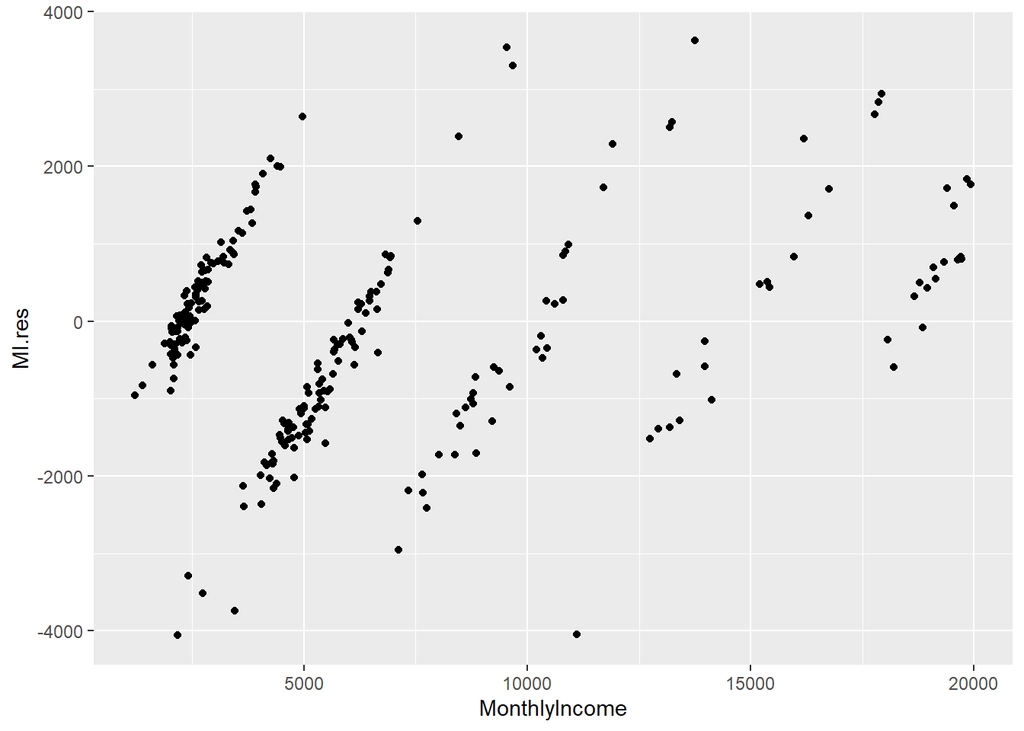

```r
test.predict <- predict(fit.train, test.mlr, interval = "confidence")
test.mlr$fit <- test.predict[, "fit"]
test.mlr$MI.res <- test.mlr$MonthlyIncome - test.mlr$fit

#dev.new()
test.mlr %>% ggplot(aes(x = MonthlyIncome, y = MI.res))+
  geom_point()
```

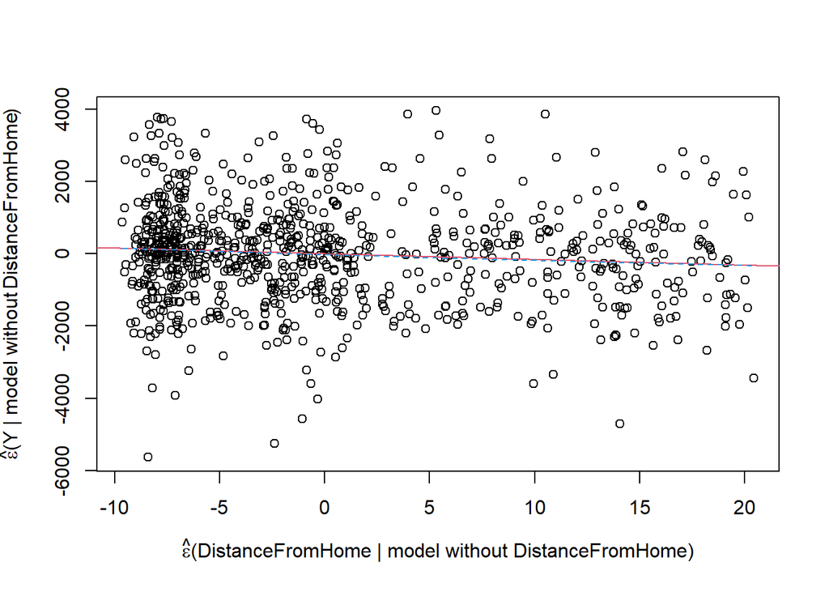

```
## Press return for next plot
```

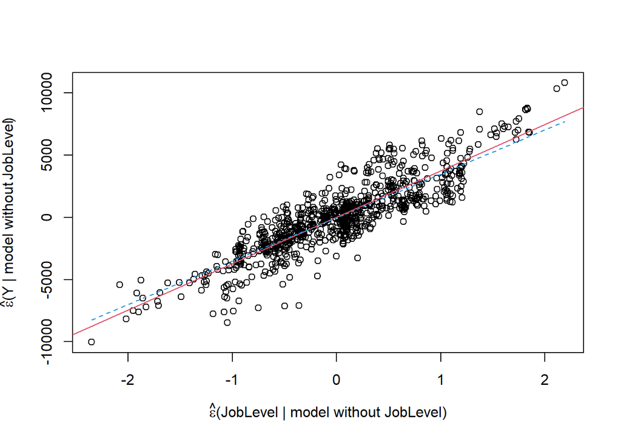

```
## Press return for next plot
```

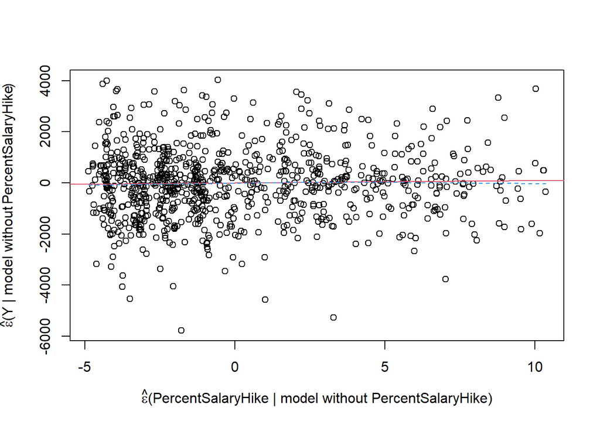

```
## Press return for next plot
```

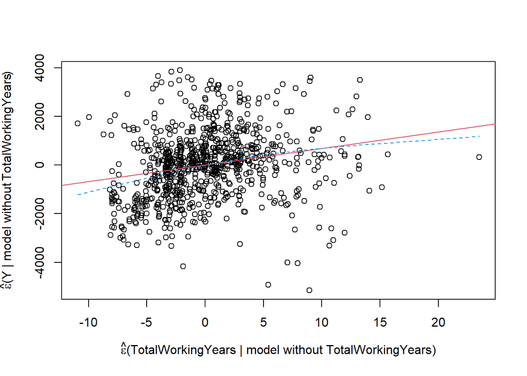

```
## Press return for next plot
```

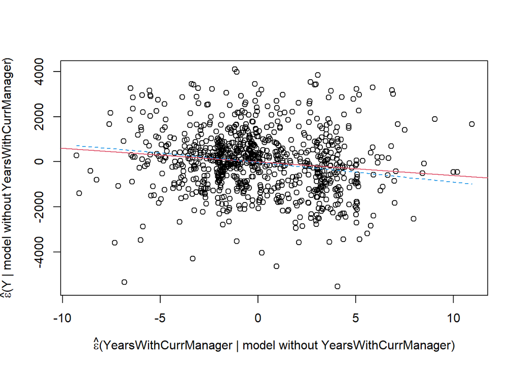

```
## Press return for next plot
```

```r
partial.resid.plot(fit2, smooth.span = 2, lf.col = 2)
```

```
## Analysis of Variance Table
##
## Response: MonthlyIncome
##                          Df   Sum Sq  Mean Sq F value  Pr(>F)
## JobLevel                  1 1.66e+10 1.66e+10 8846.00 < 2e-16 ***
## TotalWorkingYears         1 5.93e+07 5.93e+07   31.56 2.6e-08 ***
## YearsWithCurrManager      1 3.08e+07 3.08e+07   16.35 5.7e-05 ***
## DistanceFromHome          1 1.35e+07 1.35e+07    7.18  0.0075 **
## EnvironmentSatisfaction   1 5.28e+06 5.28e+06    2.81  0.0940 .
## Residuals               864 1.62e+09 1.88e+06
## ---
## Signif. codes:  0 '***' 0.001 '**' 0.01 '*' 0.05 '.' 0.1 ' ' 1
```

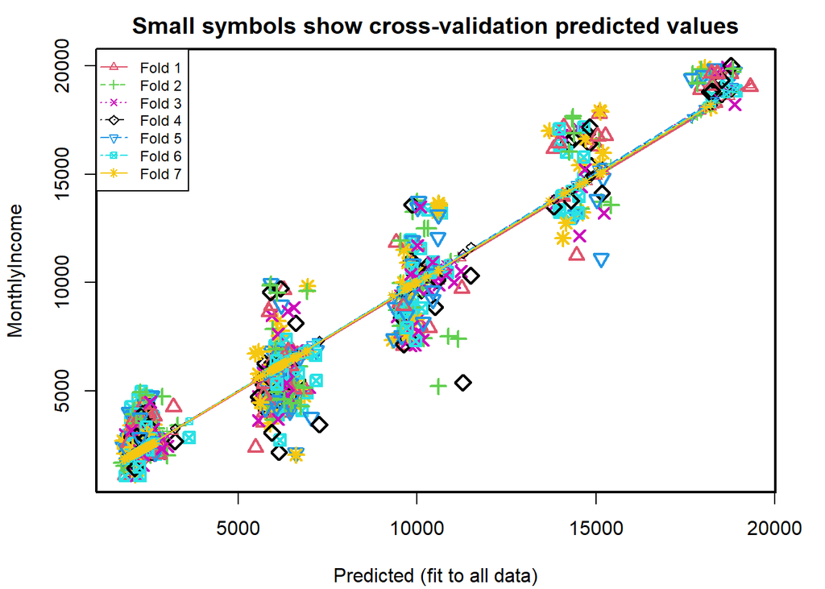

```
##
## fold 1
## Observations in test set: 124
##                  7   10     34   35   40    41    44   60    62    76   84   89
## Predicted     2432 5762 2313.2 6265 1916 15015 18400 1840  9623  6245 6234 9587
## cvpred        2431 5768 2329.8 6202 1912 14942 18222 1823  9603  6241 6224 9572
## MonthlyIncome 2127 5063 2258.0 9679 2791 16291 19613 1118  7094  4011 5974 8726
## CV residual   -304 -705  -71.8 3477  879  1349  1391 -705 -2509 -2230 -250 -846
##                  97  106   108  109   114   116   121   123  126  127   135
## Predicted     14772 2360 18764 5927  6853  9574  9989 10482 5894 2220  6325
## cvpred        14623 2401 18567 5906  6755  9586  9965 10376 5917 2241  6261
## MonthlyIncome 16606 4420 19636 8926  5093  7642 11713 10761 5204 3919  5257
## CV residual    1983 2019  1069 3020 -1662 -1944  1748   385 -713 1678 -1004
##                 138  147  154   168  182  208   212   218  232   235   237  243
## Predicted     10334 2034 6489 13825 6233 6638 18321 14106 2060 13878 17934 2280
## cvpred        10273 2045 6443 13787 6238 6536 18148 14001 2062 13824 17907 2290
## MonthlyIncome 10739 2756 6870 16184 6893 6673 18303 17174 2014 16959 18880 2703
## CV residual     466  711  427  2397  655  137   155  3173  -48  3135   973  413
##                256  263  266   273  291    298  299  302  309  310  315   327
## Predicted     2501 2227 2263  5707 2481 6150.9 2157 9511 6315 5827 6319 17960
## cvpred        2494 2223 2268  5724 2456 6158.9 2152 9513 6283 5800 6279 17890
## MonthlyIncome 2438 2436 2426  3540 2270 6074.0 2321 9069 6385 4851 5405 19049
## CV residual    -56  213  158 -2184 -186  -84.9  169 -444  102 -949 -874  1159
##                 355  382  403   404  428   431  438  448   449  458  459  474
## Predicted     10788 1872 2551 10080 2234  5868 2310 6417  5478 6288 2613 2119
## cvpred        10696 1894 2519 10026 2210  5859 2331 6352  5487 6210 2598 2095
## MonthlyIncome 10447 2942 2105  8008 3230  4478 2867 5538  2406 5441 2066 3452
## CV residual    -249 1048 -414 -2018 1020 -1381  536 -814 -3081 -769 -532 1357
##                   475  477  481  484  493  503  507   512  517   523    535
## Predicted     2204.33 6160 6285 3185 6015 2827 2067  9782 1918 11250 2142.7
## cvpred        2208.33 6088 6268 3114 5996 2801 2052  9728 1903 11103 2180.9
## MonthlyIncome 2207.00 6334 5373 4257 5869 2655 2851 10920 2413  9724 2119.0
## CV residual     -1.33  246 -895 1143 -127 -146  799  1192  510 -1379  -61.9
##                538  539  545  546  550  561    566     570  578  589   592  600
## Predicted     2388 2438 2341 2172 2006 2788 2488.4 14060.5 2361 2537  6114 2610
## cvpred        2366 2458 2340 2193 2012 2739 2483.1 13944.1 2355 2525  6125 2584
## MonthlyIncome 2696 3202 4381 2929 2177 2088 2436.0 13973.0 3162 3629  4599 2293
## CV residual    330  744 2041  736  165 -651  -47.1    28.9  807 1104 -1526 -291
##                601  608  617   622   642   643  645  647  652  660   667   670
## Predicted     1941 6023 2647  6549  6346 15267 2550 2023 6101 5996 10338 15093
```

[output cut: 374 more lines]

```
## Predicted      9733 9744 2494 1840  6161 14074 2168 1954 1950 2144 10610 2488
## cvpred         9785 9790 2460 1874  6145 14084 2164 1976 1977 2148 10548 2455
## MonthlyIncome  7655 9434 2973 2340  4765 12031 3295 2296 2323 2302 13549 3306
## CV residual   -2130 -356  513  466 -1380 -2053 1131  320  346  154  3001  851
##                  764    790  795  798   805   806  823  837    845  856   867
## Predicted     6282.9 2136.8 5569 2091  6611  9961 5480 2445 6040.6 2036  5615
## cvpred        6284.8 2140.6 5644 2094  6561  9991 5567 2414 6055.5 2051  5675
## MonthlyIncome 6347.0 2096.0 6804 2398  2042  8321 6712 2996 6029.0 2404  4465
## CV residual     62.2  -44.6 1160  304 -4519 -1670 1145  582  -26.5  353 -1210
##
## Sum of squares = 2.19e+08    Mean square = 1768845    n = 124
##
## Overall (Sum over all 124 folds)
##      ms
## 1902147
```

```r
### INTERNAL CROSS-VALIDATION of GLM ###

fit2.glm <- glm(MonthlyIncome ~ JobLevel + TotalWorkingYears + YearsWithCurrManager + DistanceFromHome + EnvironmentSatisfaction, data = employee.dB)
cv.err <- cv.glm(employee.dB, fit2.glm)$delta
cv.err.2 <- cv.glm(employee.dB, fit2.glm, K = 2)$delta
cv.err.3 <- cv.glm(employee.dB, fit2.glm, K = 3)$delta
cv.err.6 <- cv.glm(employee.dB, fit2.glm, K = 6)$delta

fit2.cv.lm <- cv.lm(employee.dB, m = 7, plotit = "Observed", form.lm = formula(MonthlyIncome ~ JobLevel + TotalWorkingYears + YearsWithCurrManager + DistanceFromHome + EnvironmentSatisfaction) )
```

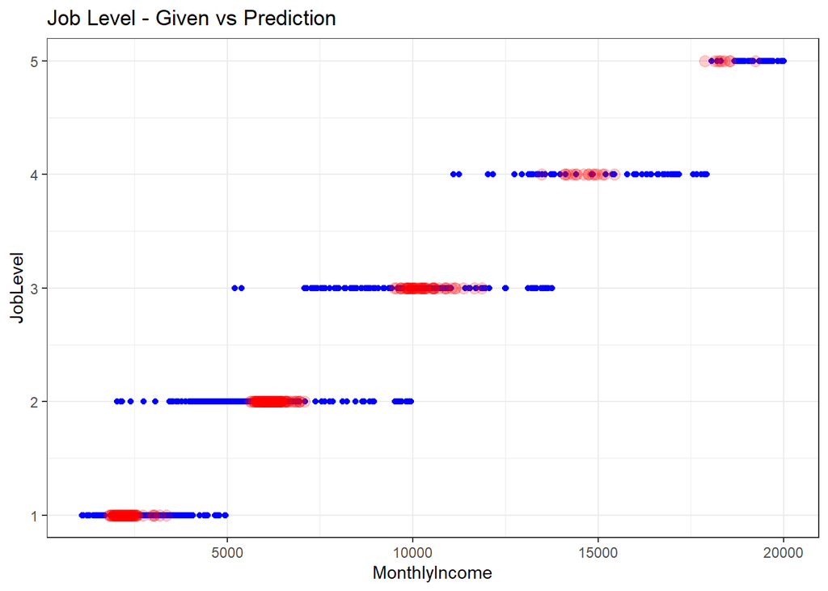

```r
############### PREFERRED MLR MODEL RUN ON BLIND DATASET FOR GRADING SUBMISSION ###############

path.mlr.prediction.dB <- "C:\\Users\\dloveday\\Dropbox\\Family\\School\\SMU\\Courses\\Spring 2021\\DS 6306 - Doing Data Science\\Lecture Notes\\Unit 14 and 15 Case Study 2\\CaseStudy2CompSet No Salary.csv"
mlr.prediction.input.dB <- read.csv(path.mlr.prediction.dB)

mlr.prediction <- predict(fit2, mlr.prediction.input.dB, interval = "confidence")
mlr.prediction.input.dB$MonthlyIncome <- mlr.prediction[, "fit"]

# Compare DistanceFromHome
#dev.new()
plot.JobLevel <-  ggplot()+
                    theme_bw()+
                    geom_point(data = employee.dB, aes(x = MonthlyIncome, y = JobLevel), color = "blue")+
                    geom_point(data = mlr.prediction.input.dB, aes(x = MonthlyIncome, y = JobLevel), color = "red", size = 3, alpha = 0.2)+
                    ggtitle("Job Level - Given vs Prediction")
multiplot(plot.JobLevel)
```

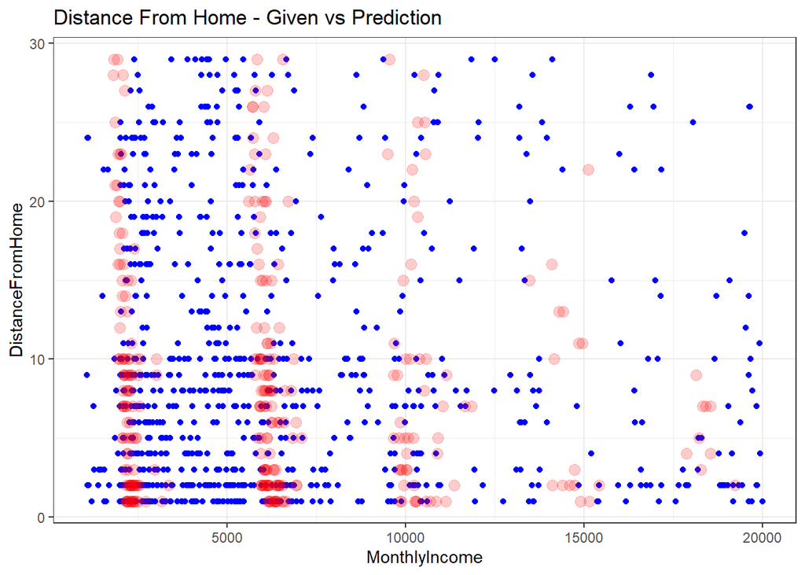

```r
#dev.new()
plot.DistanceFromHome <-  ggplot()+
                            theme_bw()+
                            geom_point(data = employee.dB, aes(x = MonthlyIncome, y = DistanceFromHome), color = "blue")+
                            geom_point(data = mlr.prediction.input.dB, aes(x = MonthlyIncome, y = DistanceFromHome), color = "red", size = 3, alpha = 0.2)+
                            ggtitle("Distance From Home - Given vs Prediction")
multiplot(plot.DistanceFromHome)
```

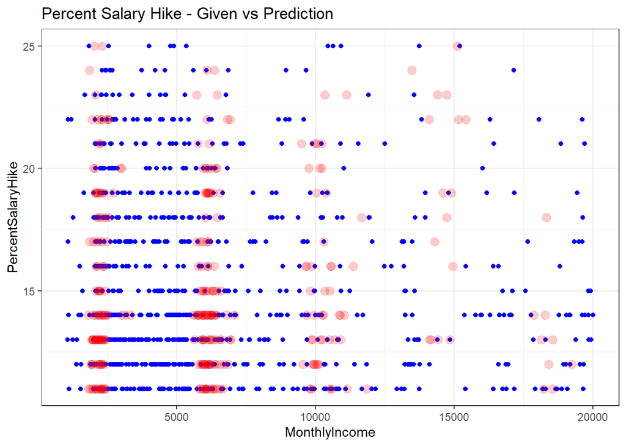

```r
#dev.new()
plot.PercentSalaryHike <-  ggplot()+
                              theme_bw()+
                              geom_point(data = employee.dB, aes(x = MonthlyIncome, y = PercentSalaryHike), color = "blue")+
                              geom_point(data = mlr.prediction.input.dB, aes(x = MonthlyIncome, y = PercentSalaryHike), color = "red", size = 3, alpha = 0.2)+
                              ggtitle("Percent Salary Hike - Given vs Prediction")
multiplot(plot.PercentSalaryHike)
```